# Random Forest Analysis of Heart Failure Dataset

Author

Sierra Landacre, Tim Leschke, Pamela Mishaw, Pallak Singh

Published

August 6, 2024

Slides

## Introduction

Correctly classifying a person for being at risk for heart failure is essential for strong preventive health care. Contributing factors are known to include coronary artery disease, hypertension, obesity, infection, certain medications, and lifestyle choices such as alcohol consumption, smoking, and drug abuse. Understanding the influences of these competing factors is made easier through unsupervised machine learning which can find patterns and insights in data without explicit human guidance or instruction. Random Forest is a promising machine learning model because it correctly classifies data from large data sets, is resistant to outliers, and is easy to use. In this report we validate the application of Random Forest machine learning to support the accurate classification of heart failure among 299 patient profiles.

### Classification with Decision Trees

At the heart of the Random Forest model is the decision tree. A decision tree “is a unidirectional, compact, tree-like data structure where each branch point is an attribute-data test that partitions the data rows into two or more branches.” (Sheppard 2017). An optimized tree is shallow and has few branches. A decision tree may be used to perform classification or regression analysis to predict a future value given particular features of a subject.

Yuan et. al. state the most influential decision tree algorithm is Iterative Dichotomiser 3 (ID3) (Yuan et al. 2015). ID3 is presented by Quinlan in his 1986 seminal paper *Induction of Decision Trees* (Quinlan 1986). This paper lays the foundation for using machine learning to address the bottleneck caused by expert systems. Quinlan demonstrates it is possible to use decision trees to generate knowledge and solve difficult problems through automation without much computation (Quinlan 1986). Low-levels of noise do not cause the tree building to “fall over a cliff” and fail (Quinlan 1986). Furthermore, training the decision tree with noise has been discovered to yield optimal results. In addition, unbalanced trees tend to perform statistically better than those balanced through stratification (Mascaro et al. 2014).

A decision tree does not have domain knowledge (Sheppard 2017). It begins as a data structure with a single node that divides the dataset into subsets according to a partitioning algorithm that learns from exposure to training data. Training data is a smaller representation of the main data set, and it contains examples of each class of datapoint found in the main data set. As the decision tree processes the training data, it grows branches and additional nodes to support the recursive partitioning of subsets into smaller subsets until this process terminates with each datapoint being assigned to a category found at each leaf node. This automated machine learning algorithm is challenged by poor-partitioning, noise, and long compute-time (Sheppard 2017).

Poor-partitioning results in elongated decision trees with impure subsets. An impure subset occurs when a branch point does not perform a pure classification. Dirty subsets lead to incorrect classifications, and ultimately to poor heart failure classification in a preventive healthcare workflow.

Noise is another challenge facing machine learning with decision trees. Noise is any impurity found within the dataset. It is random, unpredictable, and unexpected data that disrupts the ability to correctly partition data into categories. It is what some call entropy (Sheppard 2017). The more entropy there is, the more challenging it is to correctly classify each datapoint.

Long compute-time is influenced by both size and complexity of the classification dataset. Complex datasets with more categories require a decision tree with more nodes and more branches. Taller and fatter decision trees require more compute-time for processing. Pushing more data through a larger and more complex decision tree has a multiplying effect on the compute-time.

### Classification with Random Forest

Leo Breiman addresses poor-partitioning, noise, and long compute time with his proposal of the Random Forest model (Breiman 2001). Random Forest is a group of decision trees (a forest) that are created from identically distributed, independent random samples of data drawn with replacement from the original dataset (Breiman 2001). Breiman calls this random sample process a *bootstrap*, which others have re-worded as *bootstrapping*. At each node, a random subset of variables is taken from the array of features and the one that provides the best split is selected for that point. This randomness provides robustness in the presence of misclassifications and noise (Breiman 2001), (Moradi et al. 2024), (Casanova et al. 2014). This classification by aggregation is known as *ensemble learning* and is a proven approach for dealing with bad data (Sheppard 2017). Bad data, however, cannot include missing values for response or predictor variables (Brieuc et al. 2018).

Because each decision tree is processed with a different random set of data, each grows into a unique structure with a unique classification result. The final classification from Random Forest is a result of aggregating the results from each decision tree; a process Breiman calls *bagging* (Breiman 2001). This bagging technique addresses both the noise and poor-partitioning of traditional decision trees that results in inaccurate classification. By using multiple trees and aggregating the results, the effects of noise and poor-partitioning are minimized, and accuracy is increased (Breiman 2001). Furthermore, bagging can be used to calculate an “ongoing estimate of the generalization error” which is the error rate of the training set (Breiman 2001). This can be used to predict how well the model is performing during classification.

Accuracy is optimized through a process called *boosting*. Boosting is a technique by which more weight is given to the votes that come from decision trees that predict correctly versus those that do not predict correctly. Sheppard states “boosting earned a 1-2 percent overall improvement in the ability to predict the correct outcome while also achieving the percentage more consistently” (Sheppard 2017). Accuracy is also improved through a heuristic known as Ant Colony Optimization (ACO) (Boryczka and Kozak 2011). This approach is inspired by ant colony behavior in which individual ants leave traces of pheromone to communicate to other ants regarding the best path to take. Similarly, the ACO algorithm improves dataset splitting by providing feedback to subsequent splitting choices. By improving the choice of criteria to split on, one achieves “maximum homogeneity in the decision classes” which improves overall decision tree accuracy (Boryczka and Kozak 2011).

An important feature of random Forest is its ability to provide measures of how strong a given variable is associated with a classification result. These measures include *raw importance score for class 0*, *raw importance score for class 1*, *decrease in accuracy*, and the *Gini Index* (Esmaily et al. 2018). Gini Index is explained later. These scores help users fine-tune the Random Forest method so optimal classification results are achieved.

### Related Work

There are many examples of how Random Forest is used as a successful and scaleable classifier. In one study, researchers create a Random Forest model to predict in-hospital mortality for acute kidney injury patients in the intensive care unit (Lin, Hu, and Kong 2019). The Random Forest model displays the lowest Brier score (associated with accuracy) and the largest AUROC (associated with discrimination), meaning Random Forest produces the best values for these assessments of the compaired models, with the second best F1 score and accuracy.

In another experiment, researchers develope a random forest regression model capable of accurately predicting future estimated glomerular filtration rates using electronic medical record data (Zhao, Gu, and McDermaid 2019). This tool allows identification of chronic kidney disease in its early stages to more likely prevent progression into end-stage renal disease. The random forest models that are created are found to have accuracies of about 90% for stages 2 and 3, and about 80% for stages 4 and 5 of chronic kidney disease.

Scientists also investigate the accuracy of the Random Forest algorithm for the classification of gait as displaying or lacking the characteristics of hemiplegia, which is the paralysis of one side of the body (Luo et al. 2020). Researchers achieve a classification accuracy of 95.45%, which they state “is superior than all existing methods.” Because of the natural tendency for Random Forest to be resistant to over-fitting, the researchers “do not have to have careful control over the percentage of patients in the training data” (Luo et al. 2020).

When the Random Forest model is applied to the classification of persons with type 1 and type 2 diabetes, the conclusion is that “the types of attributes used have an important role in the classification process” (Rachmawanto et al. 2021). In their study, Random Forest executed with the Abel Vika dataset achieves 100% accuracy, 100% precision, and 100% recall. In contrast, when the Pima Indian Diabetes Dataset is used, the results show at most scores of 75-85% for accuracy, precision, and recall. The conclusion is that Random Forest excels when the data is noisy and unbalanced as is the case with the first dataset.

In practical applications, Random Forest’s scalability and parallelization capabilities are noteworthy, allowing it to efficiently process large datasets using parallel computing techniques like MapReduce (Yuan et al. 2015). This scalability makes random forest suitable for tasks ranging from clinical prediction in healthcare to large-scale genetic analyses, where handling big data is essential for achieving accurate and reliable results.

Random forest provides valuable insights into feature importance, aiding researchers in understanding which variables contribute most significantly to predictions. This attribute is critical in applications where identifying key factors, such as genetic markers in genome-wide association studies, environmental variables in ecological analyses, and heart failure classification is paramount. Since the Random Forest model shows robustness in the face of noisy datasets, it is an ideal algorithm for studies that involve numerous features such as those found in the biomedical sciences. Its methodology is also more easily conveyed and understood by medical professionals than many other machine learning models, allowing for greater promise in successful real-world implementation. However, in other study types Random Forest is used due to simplicity and diversity, making it one of the commonly used algorithms used for solar energy predictions (Wang et al. 2020).

In the following sections we explain the Methods pertaining to Random Forest. This includes the algorithm, measuring node purity with the *Gini Index*, and aggregation of classification votes from individual decision trees via a processes called *bagging*. The Analysis and Results section presents the classification of the Heart Failure Clinical Records dataset processed with R-code and explains how the algorithm is tuned for optimized results (“Heart Failure Clinical Records” 2020). Lastly, the Conclusion ties all of this work together and crowns Random Forest as a promising machine learning model for classifying people at risk for heart failure.

## Methods

We assume the reader knows single classification trees. A Random Forest performs classification via aggregated votes from a group of classification trees built from random data samples.

The algorithm for classification with Random Forest is provided below.  
(Copied, with additions, from (Hastie, Tibshirani, and Friednman 2001)).

```
Random Forest Algorithm
```

1. For b = 1 to B where B is the number of trees in the forest:
   1. Draw a bootstrap sample **Z*** of size *N* from the training data.
   2. Grow a random-forest tree *T<sub>b</sub>* to the bootstrapped data, by recursively repeating the following steps for each terminal node of the tree, until the minimum node size *n<sub>min</sub>* is reached.
   1. Select *m* variables at random from the *p* variables.
   2. Pick the best variable/split-point among the *m*.
   3. Split the node into two daughter nodes.
2. Output the ensemble of trees.

To make a classification prediction at a new point *x*:

Let *Ĉ<sub>b</sub>(*x*)* be the class prediction of the *b*th random-forest tree. Then *Ĉ<sub>rf</sub><sup>B</sup>(*x*) = *majority vote* {Ĉ<sub>b</sub>(*x*)}<sub>1</sub><sup>B</sup>*.

Figure 1 shows the generation of a Random Forest. The uniqueness of each tree, as a result of random data samples, allows the ensemble to avoid misclassification, and improve classification accuracy.

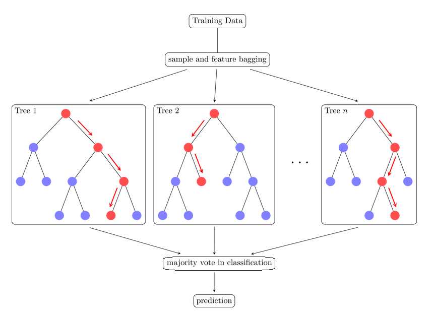

Figure 1. (Modified from TikZ.net, https://tikz.net/random-forest/, accessed 7/13/2024)

The *Gini Index* is referred to as a measure of node purity (James et al. 2021). It can also be used to measure the importance of each predictor. The Gini Index is defined by the following formula where K is the number of classes and ${\hat{p}_{mk}}$ is the proportion of observations in the *m*th region that are from the *k*th class. A Gini Index of 0 represents perfect purity.

$$D=-\sum_{n=1}^{K} {\hat{p}_{mk}}(1-\hat{p}_{mk})$$

*Bagging* is the aggregation of the results from each decision tree. It is defined by the following formula where B is the number of training sets and $\hat{f}^{*b}$ is the prediction model. Although bagging improves prediction accuracy, it makes interpreting the results harder as they cannot be visualized as easily as a single decision tree (James et al. 2021).

$${\hat{f}bag(x) = 1/B \sum_{b=1}^{B}\hat{f}^{*b}(x)}$$

## Analysis and Results

In the following section we ingest the data into R-Studio, perform classification with Random Forest, and perform analysis. Raw output is displayed for completeness. We typeset the output when appropriate and use visualization techniques to enhance understanding. We comment extensively in an effort to explain each step in the analytic process.

### The Heart Failure Dataset

The Random Forest classification method is implemented in the Heart Failure Clinical Records dataset provided by the University of California Irvine Machine Learning Repository (“Heart Failure Clinical Records” 2020). The dataset comes from the Faisalabad Institute of Cardiology and the Allied Hospital in Faisalabad Pakistan and consists of the medical records of 299 patients; some who experienced heart failure (Chicco and Jurman 2020). There are 299 patient records with 13 features per record. We use this dataset to create and evaluate a Random Forest model used for predicting heart failure events for patients.

The features of the Heart Failure Clinical Records dataset are provided in the table below:

```
             Feature.Name       Type
1                     age    integer
2                  anemia     binary
3  creatine_phosphokinase    integer
4                diabetes     binary
5       ejection_fraction    integer
6     high_blood_pressure     binary
7               platelets continuous
8        serum_creatinine continuous
9            serum_sodium    integer
10                    sex     binary
11                smoking     binary
12                   time    integer
13            death_event     binary
                                                 Description
1                                             age of patient
2                  decrease of red blood cells or hemoglobin
3                       level of the CPK enzyme in the blood
4                                if the patient has diabetes
5  percentage of blood leaving the heart at each contraction
6                            if the patient has hypertension
7                                     platelets in the blood
8                     level of serum creatinine in the blood
9                         level of serum sodium in the blood
10                                              woman or man
11                              if the patient smokes or not
12                                  follow-up period in days
13           if the patient died during the follow-up period
```

Heart Failure Clinical Records - UCI Machine Learning Repository

| Feature Name | Description |
| --- | --- |
| Age (integer) | Age of patient |
| Anemia (binary*) | Decrease of red blood cell or hemoglobin |
| Creatine Phosphokinase (integer) | Level of CPK enzyme in the blood |
| Diabetes (binary*) | If the patient has diabetes |
| Ejection Fraction (integer) | Percentage of blood leaving the heart at each contraction |
| High Blood Pressure (binary*) | If the patient has hypertension |
| Platelets (continuous) | Platelets in the blood |
| Serum Creatinine (continuous) | Level of serum creatine in the blood |
| Serum Sodium (integer) | Level of serum sodium in the blood |
| Sex (binary, 0 = female, 1 = male) | Woman or Man |
| Smoking (binary*) | If the patient smokes or not |
| Time (integer) | Follow-up period in days |
| Death Event (binary*) | If the patient died during the follow-up period |

* Binary features; 0 = “no” and 1 = “yes”.

Source: (“Heart Failure Clinical Records” 2020)

### Software and Hardware Configuration

The R programming language is used to support data processing and analysis as it is the standard for statistical programming and graphics.

RStudio Pro, 2023.12.0, Build 369.pro3 is used. Various R libraries and packages are employed including CaTools, RandomForest, Tidyverse, Readr, Dplyr, Party, Caret, Corrplot, Tidyr, Ggplot2, DT, and pRoc.

```r
#{r, echo=FALSE}
install.packages("caTools", repos="http://cran.us.r-project.org")
install.packages("randomForest", repos="http://cran.us.r-project.org")
install.packages("tidyverse", repos="http://cran.us.r-project.org")
install.packages("dplyr", repos="http://cran.us.r-project.org")
install.packages("party", repos="http://cran.us.r-project.org")
install.packages("DescTools", repos="http://cran.us.r-project.org") # for Gini index
install.packages("ggplot2", repos="http://cran.us.r-project.org")

library(caTools)
library(randomForest)
library(tidyverse)
library(readr)
library(dplyr)
library(party)
library(caret)
library(corrplot)
library(DescTools) # for Gini index
library(ggplot2)
```

The RStudio Server is running on a RHEL9 based virtual machine within a VMware VSphere HA cluster. The VM itself has 50 vCPU’s and 196 GB of ram assigned.

The physical hardware of the cluster nodes are Dell PowerEdge R750 servers with Dual Xeon Gold 6338N (32 core) CPU’s, 512 GB of ram, and sfp28 25gbit networking for all communications (6 total sfp28 per server). Cluster storage is from a NVMe based Dell SAN.

### Loading and Examining the Dataset

The heart failure dataset is loaded from a .csv file.

The dataset is checked for any null values, and none are found. Null values can cause errors in calculations and need to be addressed, often by removing them or providing a value for them (a median value, a random value, or something else).

```r
#{r, echo=FALSE}
# What does this code do?
heart_df %>% summarise(across(everything(), ~ sum(is.na(.))))
```

```
# A tibble: 1 × 13
    age anaemia creatinine_phosphokinase diabetes ejection_fraction
  <int>   <int>                    <int>    <int>             <int>
1     0       0                        0        0                 0
# ℹ 8 more variables: high_blood_pressure <int>, platelets <int>,
#   serum_creatinine <int>, serum_sodium <int>, sex <int>, smoking <int>,
#   time <int>, DEATH_EVENT <int>
```

The target variable (DEATH_EVENT) is examined for the balance between the negative and positive classes.

```r
#{r, echo=FALSE}
heart_df %>% count(DEATH_EVENT)
```

```
# A tibble: 2 × 2
  DEATH_EVENT     n
        <dbl> <int>
1           0   203
2           1    96
```

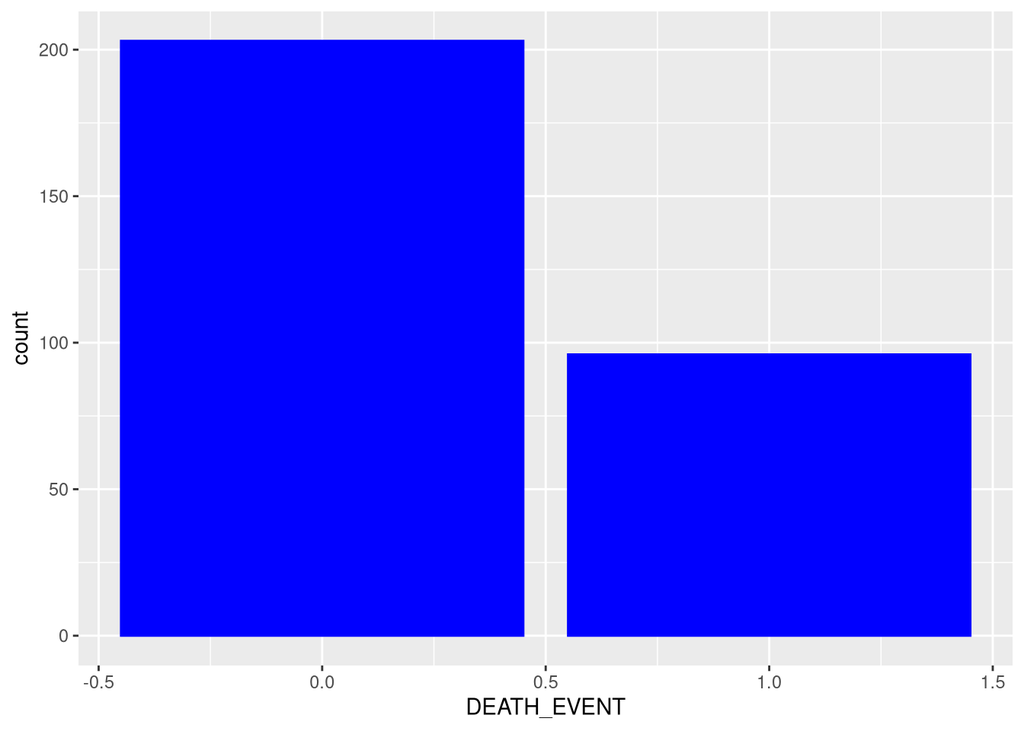

```r
ggplot(data = heart_df) +
  geom_bar(mapping = aes(x = DEATH_EVENT), fill="blue", color="blue")
```

```r
# heart_df <- heart_df %>%
#   mutate(across(where(is.numeric), as.factor))
#
# col_names <- colnames(heart_df)
# col_names <- col_names[-1]
#
# # plot_list <- list()
#
# for (i in col_names){
#     # df[,i] <- as.factor(df[,i])
#     plot <- ggplot(data = heart_df, aes(x = i)) +
#     geom_bar()+
#       xlab(i)
#     print(plot)
# }
```

The DEATH_EVENT feature is converted to a factor feature since it is the binary dependent variable.

```r
#{r, echo=FALSE}
heart_df$DEATH_EVENT = as.factor(heart_df$DEATH_EVENT)
```

The number of negative events (non-heart-failure events) are found to be about double the number of positive events (heart-failure events). This imbalance is not considered significant as the Random Forest algorithm is robust enough to tolerate this asymmetry.

### Fitting the Dataset

We fit the dataset by calculating the *Gini Index* for each of the remaining variables and display them in the table that follows.

```r
# heart_df is the original data frame created with the import of the entire dataset
head(heart_df)
```

```
# A tibble: 6 × 13
    age anaemia creatinine_phosphokinase diabetes ejection_fraction
  <dbl>   <dbl>                    <dbl>    <dbl>             <dbl>
1    75       0                      582        0                20
2    55       0                     7861        0                38
3    65       0                      146        0                20
4    50       1                      111        0                20
5    65       1                      160        1                20
6    90       1                       47        0                40
# ℹ 8 more variables: high_blood_pressure <dbl>, platelets <dbl>,
#   serum_creatinine <dbl>, serum_sodium <dbl>, sex <dbl>, smoking <dbl>,
#   time <dbl>, DEATH_EVENT <fct>
```

```r
# Create a heart data vector
heart_dv = select(heart_df, smoking, high_blood_pressure, creatinine_phosphokinase, diabetes, anaemia, sex, time, serum_creatinine, platelets, ejection_fraction, age, serum_sodium, DEATH_EVENT)

#heart_dv = select(heart_df, age, creatinine_phosphokinase, ejection_fraction, platelets, serum_creatinine, serum_sodium, time, anaemia, diabetes, high_blood_pressure, sex, smoking, DEATH_EVENT)

# heart_df_noBinary is the dataset with all binary variables, except DEATH_EVENT, removed
heart_df_noBinary = select(heart_df, age, creatinine_phosphokinase, ejection_fraction, platelets, serum_creatinine, serum_sodium, time, DEATH_EVENT)

head(heart_df_noBinary)
```

```
# A tibble: 6 × 8
    age creatinine_phosphokinase ejection_fraction platelets serum_creatinine
  <dbl>                    <dbl>             <dbl>     <dbl>            <dbl>
1    75                      582                20   265000               1.9
2    55                     7861                38   263358.              1.1
3    65                      146                20   162000               1.3
4    50                      111                20   210000               1.9
5    65                      160                20   327000               2.7
6    90                       47                40   204000               2.1
# ℹ 3 more variables: serum_sodium <dbl>, time <dbl>, DEATH_EVENT <fct>
```

```r
ageVector <- heart_dv$age
GiniIndex_AgeVector <- Gini(ageVector, unbiased=FALSE)
GiniIndex_AgeVector # the output is [1] 0.1101127
```

```
[1] 0.1101127
```

```r
cpVector <- heart_dv$creatinine_phosphokinase
GiniIndex_cpVector <- Gini(cpVector, unbiased=FALSE)
GiniIndex_cpVector # the output is [1] 0.6082741
```

```
[1] 0.6082741
```

```r
efVector <- heart_dv$ejection_fraction
GiniIndex_efVector <- Gini(efVector, unbiased=FALSE)
GiniIndex_efVector # the output is [1] 0.1712855
```

```
[1] 0.1712855
```

```r
plateletsVector <- heart_dv$platelets
GiniIndex_plateletsVector <- Gini(plateletsVector, unbiased=FALSE)
GiniIndex_plateletsVector # the output is [1] 0.1909926
```

```
[1] 0.1909926
```

```r
scVector <- heart_dv$serum_creatinine
GiniIndex_scVector <- Gini(scVector, unbiased=FALSE)
GiniIndex_scVector  # the output is [1] 0.2799149
```

```
[1] 0.2799149
```

```r
ssVector <- heart_dv$serum_sodium
GiniIndex_ssVector <- Gini(ssVector, unbiased=FALSE)
GiniIndex_ssVector  # The output is [1] 0.01707994
```

```
[1] 0.01707994
```

```r
timeVector <- heart_dv$time
GiniIndex_timeVector <- Gini(timeVector, unbiased=FALSE)
GiniIndex_timeVector  # The output is [1] 0.3416812
```

```
[1] 0.3416812
```

```r
anaemiaVector <- heart_dv$anaemia
GiniIndex_anaemiaVector <- Gini(anaemiaVector, unbiased=FALSE)
GiniIndex_anaemiaVector  # The output is
```

```
[1] 0.5685619
```

```r
diabetesVector <- heart_dv$diabetes
GiniIndex_diabetesVector <- Gini(diabetesVector, unbiased=FALSE)
GiniIndex_diabetesVector  # The output is
```

```
[1] 0.5819398
```

```r
highBloodPressureVector <- heart_dv$high_blood_pressure
GiniIndex_highBloodPressureVector <- Gini(highBloodPressureVector, unbiased=FALSE)
GiniIndex_highBloodPressureVector  # The output is
```

```
[1] 0.6488294
```

```r
sexVector <- heart_dv$sex
GiniIndex_sexVector <- Gini(sexVector, unbiased=FALSE)
GiniIndex_sexVector  # The output is
```

```
[1] 0.3511706
```

```r
smokingVector <- heart_dv$smoking
GiniIndex_smokingVector <- Gini(smokingVector, unbiased=FALSE)
GiniIndex_smokingVector  # The output is
```

```
[1] 0.6789298
```

```r
# BELOW IS A SUMMARY OF THE RESULTS
#
# smoking                   0.6789
# high blood pressure       0.6488
# creatinine_phosphokinase  0.6082741
# diabetes                  0.5819
# anaemia                   0.5686
# sex                       0.3512
# time                      0.3416812
# serum_creatinine          0.2799149
# platelets                 0.1909926
# ejection_fraction         0.1712855
# Age                         0.1101127
# serum_sodium              0.01707994
```

Gini Index Table

| Variable | Gini Index |
| --- | --- |
| Smoking (S) | 0.6789 |
| High Blood Pressure (HBP) | 0.6488 |
| Creatinine_Phosphokinase (CP) | 0.6082741 |
| Diabetes (D) | 0.5819 |
| Anaemia (AN) | 0.5686 |
| Sex (S) | 0.3512 |
| Time (T) | 0.3416812 |
| Serum_Creatinine (SC) | 0.2799149 |
| Platelets (P) | 0.1909926 |
| Ejection_Fraction (EF) | 0.1712855 |
| Age (A) | 0.1101127 |
| Serum_Sodium (SS) | 0.01707994 |

```r
#{r, echo=FALSE}

heart_df_noBinary <- select(heart_df, -c(anaemia, diabetes, high_blood_pressure, sex, smoking, DEATH_EVENT))

cor_matrix <- cor(heart_df_noBinary)

#corrplot(cor_matrix, method = "color")
# The drawing of the correlation heatmap was moved to way below.  However, some of this
# code is needed earlier, so it was not moved.
```

### Permutations of the Model

We create multiple permutations of the model, and with each permutation we remove the variable with the lowest Gini Index. We also calculate the Out of Bag (OOB) estimate of error and display this as ‘1 - OOB.’ We display the results in the table that follows.

```r
#  Below we are creating datasets based on Gini Coefficients.  We begin with all variables
# and then remove the variable with the lowest Gini Coefficient as we create new datasets

# BELOW IS A SUMMARY OF THE RESULTS
#
# smoking                   0.6789
# high blood pressure       0.6488
# creatinine_phosphokinase  0.6082741
# diabetes                  0.5819
# anaemia                   0.5686
# sex                       0.3512
# time                      0.3416812
# serum_creatinine          0.2799149
# platelets                 0.1909926
# ejection_fraction         0.1712855
# Age                         0.1101127
# serum_sodium              0.01707994

heart_dv_noSerumSodium = select(heart_df, smoking, high_blood_pressure, creatinine_phosphokinase, diabetes, anaemia, sex, time, serum_creatinine, platelets, ejection_fraction, age, DEATH_EVENT)

heart_dv_noAge = select(heart_df, smoking, high_blood_pressure, creatinine_phosphokinase, diabetes, anaemia, sex, time, serum_creatinine, platelets, ejection_fraction, DEATH_EVENT)

heart_dv_noEjection_Fraction = select(heart_df, smoking, high_blood_pressure, creatinine_phosphokinase, diabetes, anaemia, sex, time, serum_creatinine, platelets, DEATH_EVENT)

heart_dv_noPlatelets = select(heart_df, smoking, high_blood_pressure, creatinine_phosphokinase, diabetes, anaemia, sex, time, serum_creatinine, DEATH_EVENT)

heart_dv_noSerum_Creatinine = select(heart_df, smoking, high_blood_pressure, creatinine_phosphokinase, diabetes, anaemia, sex, time, DEATH_EVENT)

heart_dv_noTime = select(heart_df, smoking, high_blood_pressure, creatinine_phosphokinase, diabetes, anaemia, sex, DEATH_EVENT)

heart_dv_noSex = select(heart_df, smoking, high_blood_pressure, creatinine_phosphokinase, diabetes, anaemia, DEATH_EVENT)

heart_dv_noAnaemia = select(heart_df, smoking, high_blood_pressure, creatinine_phosphokinase, diabetes, DEATH_EVENT)

heart_dv_noDiabetes = select(heart_df, smoking, high_blood_pressure, creatinine_phosphokinase, DEATH_EVENT)

heart_dv_noCreatinine_Phosphokinase = select(heart_df, smoking, high_blood_pressure, DEATH_EVENT)

heart_dv_noHigh_Blood_Pressure = select(heart_df, smoking, DEATH_EVENT)

#heart_df_noBinary_noSerum_sodium = select(heart_df, age, creatinine_phosphokinase, ejection_fraction, platelets, serum_creatinine, time, DEATH_EVENT)

# heart_df_noBinary_noAge contains the following variables
# creatinine_phosphokinase
# time
# serum_creatinine
# platelets
# ejection_fraction
#heart_df_noBinary_noAge = select(heart_df, creatinine_phosphokinase, ejection_fraction, platelets, serum_creatinine, time, DEATH_EVENT)

# heart_df_noBinary_noEjection_fraction contains the following variables
# creatinine_phosphokinase
# time
# serum_creatinine
# platelets
#heart_df_noBinary_noEjection_fraction = select(heart_df, creatinine_phosphokinase, platelets, serum_creatinine, time, DEATH_EVENT)

# heart_df_noBinary_noPlatelets contains the following variables
# creatinine_phosphokinase
# time
# serum_creatinine
# platelets
#heart_df_noBinary_noPlatelets = select(heart_df, creatinine_phosphokinase, serum_creatinine, time, DEATH_EVENT)

# heart_df_noBinary_noSerum_creatinine contains the following variables
# creatinine_phosphokinase
# time
#heart_df_noBinary_noSerum_creatinine = select(heart_df, creatinine_phosphokinase, time, DEATH_EVENT)

# heart_df_noBinary_noTime contains the following variables
# creatinine_phosphokinase
#heart_df_noBinary_noTime = select(heart_df, creatinine_phosphokinase, DEATH_EVENT)
```

## Below all

```r
# Below is Random Forest performance for heart_dv

# split the data, 80% goes to training and 20% goes to testing

set.seed(123)
samp <- sample(nrow(heart_dv), 0.8 * nrow(heart_dv))

# heart_train_all is the model with all variables
heart_train_all <- heart_dv[samp, ]
heart_test_all <- heart_dv[-samp, ]

set.seed(123)
model <- randomForest(
  formula = DEATH_EVENT~.,
  data = heart_train_all,
  importance = TRUE
)

model
```

```
Call:
 randomForest(formula = DEATH_EVENT ~ ., data = heart_train_all,      importance = TRUE)
               Type of random forest: classification
                     Number of trees: 500
No. of variables tried at each split: 3

        OOB estimate of  error rate: 13.81%
Confusion matrix:
    0  1 class.error
0 148 13  0.08074534
1  20 58  0.25641026
```

```r
prediction <- predict(model, newdata = heart_test_all)

cf <- confusionMatrix(prediction, heart_test_all$DEATH_EVENT, positive = "1", mode = "everything")
cf
```

```
Confusion Matrix and Statistics

          Reference
Prediction  0  1
         0 35  6
         1  7 12

               Accuracy : 0.7833
                 95% CI : (0.658, 0.8793)
    No Information Rate : 0.7
    P-Value [Acc > NIR] : 0.09996

                  Kappa : 0.4922

 Mcnemar's Test P-Value : 1.00000

            Sensitivity : 0.6667
            Specificity : 0.8333
         Pos Pred Value : 0.6316
         Neg Pred Value : 0.8537
              Precision : 0.6316
                 Recall : 0.6667
                     F1 : 0.6486
             Prevalence : 0.3000
         Detection Rate : 0.2000
   Detection Prevalence : 0.3167
      Balanced Accuracy : 0.7500

       'Positive' Class : 1
```

## Below noSerumSodium

```r
# Below is Random Forest performance for heart_dv_noSerumSodium

# split the data, 80% goes to training and 20% goes to testing

set.seed(123)
samp <- sample(nrow(heart_dv_noSerumSodium), 0.8 * nrow(heart_dv_noSerumSodium))

heart_train_noSerumSodium <- heart_dv_noSerumSodium[samp, ]
heart_test_noSerumSodium <- heart_dv_noSerumSodium[-samp, ]

set.seed(123)
model <- randomForest(
  formula = DEATH_EVENT~.,
  data = heart_train_noSerumSodium,
  importance = TRUE
)

model
```

```
Call:
 randomForest(formula = DEATH_EVENT ~ ., data = heart_train_noSerumSodium,      importance = TRUE)
               Type of random forest: classification
                     Number of trees: 500
No. of variables tried at each split: 3

        OOB estimate of  error rate: 12.97%
Confusion matrix:
    0  1 class.error
0 148 13  0.08074534
1  18 60  0.23076923
```

```r
prediction <- predict(model, newdata = heart_test_noSerumSodium)

cf <- confusionMatrix(prediction, heart_test_noSerumSodium$DEATH_EVENT, positive = "1", mode = "everything")
cf
```

```
Confusion Matrix and Statistics

          Reference
Prediction  0  1
         0 36  6
         1  6 12

               Accuracy : 0.8
                 95% CI : (0.6767, 0.8922)
    No Information Rate : 0.7
    P-Value [Acc > NIR] : 0.05677

                  Kappa : 0.5238

 Mcnemar's Test P-Value : 1.00000

            Sensitivity : 0.6667
            Specificity : 0.8571
         Pos Pred Value : 0.6667
         Neg Pred Value : 0.8571
              Precision : 0.6667
                 Recall : 0.6667
                     F1 : 0.6667
             Prevalence : 0.3000
         Detection Rate : 0.2000
   Detection Prevalence : 0.3000
      Balanced Accuracy : 0.7619

       'Positive' Class : 1
```

## Below noAge

```r
# Below is Random Forest performance for heart_dv_noAge

# split the data, 80% goes to training and 20% goes to testing

set.seed(123)
samp <- sample(nrow(heart_dv_noAge), 0.8 * nrow(heart_dv_noAge))

heart_train_noAge <- heart_dv_noAge[samp, ]
heart_test_noAge <- heart_dv_noAge[-samp, ]

set.seed(123)
model <- randomForest(
  formula = DEATH_EVENT~.,
  data = heart_train_noAge,
  importance = TRUE
)

model
```

```
Call:
 randomForest(formula = DEATH_EVENT ~ ., data = heart_train_noAge,      importance = TRUE)
               Type of random forest: classification
                     Number of trees: 500
No. of variables tried at each split: 3

        OOB estimate of  error rate: 13.39%
Confusion matrix:
    0  1 class.error
0 148 13  0.08074534
1  19 59  0.24358974
```

```r
prediction <- predict(model, newdata = heart_test_noAge)

cf <- confusionMatrix(prediction, heart_test_noAge$DEATH_EVENT, positive = "1", mode = "everything")
cf
```

```
Confusion Matrix and Statistics

          Reference
Prediction  0  1
         0 36  6
         1  6 12

               Accuracy : 0.8
                 95% CI : (0.6767, 0.8922)
    No Information Rate : 0.7
    P-Value [Acc > NIR] : 0.05677

                  Kappa : 0.5238

 Mcnemar's Test P-Value : 1.00000

            Sensitivity : 0.6667
            Specificity : 0.8571
         Pos Pred Value : 0.6667
         Neg Pred Value : 0.8571
              Precision : 0.6667
                 Recall : 0.6667
                     F1 : 0.6667
             Prevalence : 0.3000
         Detection Rate : 0.2000
   Detection Prevalence : 0.3000
      Balanced Accuracy : 0.7619

       'Positive' Class : 1
```

## Below noEjection_Fraction

```r
# Below is Random Forest performance for heart_dv_noEjection_Fraction

# split the data, 80% goes to training and 20% goes to testing

set.seed(123)
samp <- sample(nrow(heart_dv_noEjection_Fraction), 0.8 * nrow(heart_dv_noEjection_Fraction))

heart_train_noEjection_Fraction <- heart_dv_noEjection_Fraction[samp, ]
heart_test_noEjection_Fraction <- heart_dv_noEjection_Fraction[-samp, ]

set.seed(123)
model <- randomForest(
  formula = DEATH_EVENT~.,
  data = heart_train_noEjection_Fraction,
  importance = TRUE
)

model
```

```
Call:
 randomForest(formula = DEATH_EVENT ~ ., data = heart_train_noEjection_Fraction,      importance = TRUE)
               Type of random forest: classification
                     Number of trees: 500
No. of variables tried at each split: 3

        OOB estimate of  error rate: 15.9%
Confusion matrix:
    0  1 class.error
0 145 16  0.09937888
1  22 56  0.28205128
```

```r
prediction <- predict(model, newdata = heart_test_noEjection_Fraction)

cf <- confusionMatrix(prediction, heart_test_noEjection_Fraction$DEATH_EVENT, positive = "1", mode = "everything")
cf
```

```
Confusion Matrix and Statistics

          Reference
Prediction  0  1
         0 37  7
         1  5 11

               Accuracy : 0.8
                 95% CI : (0.6767, 0.8922)
    No Information Rate : 0.7
    P-Value [Acc > NIR] : 0.05677

                  Kappa : 0.5082

 Mcnemar's Test P-Value : 0.77283

            Sensitivity : 0.6111
            Specificity : 0.8810
         Pos Pred Value : 0.6875
         Neg Pred Value : 0.8409
              Precision : 0.6875
                 Recall : 0.6111
                     F1 : 0.6471
             Prevalence : 0.3000
         Detection Rate : 0.1833
   Detection Prevalence : 0.2667
      Balanced Accuracy : 0.7460

       'Positive' Class : 1
```

# Below noPlatelets

```r
# Below is Random Forest performance for heart_dv_noPlatelets

# split the data, 80% goes to training and 20% goes to testing

set.seed(123)
samp <- sample(nrow(heart_dv_noPlatelets), 0.8 * nrow(heart_dv_noPlatelets))

heart_train_noPlatelets <- heart_dv_noPlatelets[samp, ]
heart_test_noPlatelets <- heart_dv_noPlatelets[-samp, ]

set.seed(123)
model <- randomForest(
  formula = DEATH_EVENT~.,
  data = heart_train_noPlatelets,
  importance = TRUE
)

model
```

```
Call:
 randomForest(formula = DEATH_EVENT ~ ., data = heart_train_noPlatelets,      importance = TRUE)
               Type of random forest: classification
                     Number of trees: 500
No. of variables tried at each split: 2

        OOB estimate of  error rate: 14.64%
Confusion matrix:
    0  1 class.error
0 151 10   0.0621118
1  25 53   0.3205128
```

```r
prediction <- predict(model, newdata = heart_test_noPlatelets)

cf <- confusionMatrix(prediction, heart_test_noPlatelets$DEATH_EVENT, positive = "1", mode = "everything")
cf
```

```
Confusion Matrix and Statistics

          Reference
Prediction  0  1
         0 38  8
         1  4 10

               Accuracy : 0.8
                 95% CI : (0.6767, 0.8922)
    No Information Rate : 0.7
    P-Value [Acc > NIR] : 0.05677

                  Kappa : 0.4915

 Mcnemar's Test P-Value : 0.38648

            Sensitivity : 0.5556
            Specificity : 0.9048
         Pos Pred Value : 0.7143
         Neg Pred Value : 0.8261
              Precision : 0.7143
                 Recall : 0.5556
                     F1 : 0.6250
             Prevalence : 0.3000
         Detection Rate : 0.1667
   Detection Prevalence : 0.2333
      Balanced Accuracy : 0.7302

       'Positive' Class : 1
```

## Below noSerum_Creatinine

```r
# Below is Random Forest performance for heart_dv_noSerum_Creatinine

# split the data, 80% goes to training and 20% goes to testing

set.seed(123)
samp <- sample(nrow(heart_dv_noSerum_Creatinine), 0.8 * nrow(heart_dv_noSerum_Creatinine))

heart_train_noSerum_Creatinine <- heart_dv_noSerum_Creatinine[samp, ]
heart_test_noSerum_Creatinine <- heart_dv_noSerum_Creatinine[-samp, ]

set.seed(123)
model <- randomForest(
  formula = DEATH_EVENT~.,
  data = heart_train_noSerum_Creatinine,
  importance = TRUE
)

model
```

```
Call:
 randomForest(formula = DEATH_EVENT ~ ., data = heart_train_noSerum_Creatinine,      importance = TRUE)
               Type of random forest: classification
                     Number of trees: 500
No. of variables tried at each split: 2

        OOB estimate of  error rate: 16.32%
Confusion matrix:
    0  1 class.error
0 152  9  0.05590062
1  30 48  0.38461538
```

```r
prediction <- predict(model, newdata = heart_test_noSerum_Creatinine)

cf <- confusionMatrix(prediction, heart_test_noSerum_Creatinine$DEATH_EVENT, positive = "1", mode = "everything")
cf
```

```
Confusion Matrix and Statistics

          Reference
Prediction  0  1
         0 39  9
         1  3  9

               Accuracy : 0.8
                 95% CI : (0.6767, 0.8922)
    No Information Rate : 0.7
    P-Value [Acc > NIR] : 0.05677

                  Kappa : 0.4737

 Mcnemar's Test P-Value : 0.14891

            Sensitivity : 0.5000
            Specificity : 0.9286
         Pos Pred Value : 0.7500
         Neg Pred Value : 0.8125
              Precision : 0.7500
                 Recall : 0.5000
                     F1 : 0.6000
             Prevalence : 0.3000
         Detection Rate : 0.1500
   Detection Prevalence : 0.2000
      Balanced Accuracy : 0.7143

       'Positive' Class : 1
```

## Below noTime

```r
# Below is Random Forest performance for heart_dv_noTime

# split the data, 80% goes to training and 20% goes to testing

set.seed(123)
samp <- sample(nrow(heart_dv_noTime), 0.8 * nrow(heart_dv_noTime))

heart_train_noTime <- heart_dv_noTime[samp, ]
heart_test_noTime <- heart_dv_noTime[-samp, ]

set.seed(123)
model <- randomForest(
  formula = DEATH_EVENT~.,
  data = heart_train_noTime,
  importance = TRUE
)

model
```

```
Call:
 randomForest(formula = DEATH_EVENT ~ ., data = heart_train_noTime,      importance = TRUE)
               Type of random forest: classification
                     Number of trees: 500
No. of variables tried at each split: 2

        OOB estimate of  error rate: 34.73%
Confusion matrix:
    0 1 class.error
0 156 5   0.0310559
1  78 0   1.0000000
```

```r
prediction <- predict(model, newdata = heart_test_noTime)

cf <- confusionMatrix(prediction, heart_test_noTime$DEATH_EVENT, positive = "1", mode = "everything")
cf
```

```
Confusion Matrix and Statistics

          Reference
Prediction  0  1
         0 41 16
         1  1  2

               Accuracy : 0.7167
                 95% CI : (0.5856, 0.8255)
    No Information Rate : 0.7
    P-Value [Acc > NIR] : 0.451436

                  Kappa : 0.1146

 Mcnemar's Test P-Value : 0.000685

            Sensitivity : 0.11111
            Specificity : 0.97619
         Pos Pred Value : 0.66667
         Neg Pred Value : 0.71930
              Precision : 0.66667
                 Recall : 0.11111
                     F1 : 0.19048
             Prevalence : 0.30000
         Detection Rate : 0.03333
   Detection Prevalence : 0.05000
      Balanced Accuracy : 0.54365

       'Positive' Class : 1
```

## Below noSex

```r
# Below is Random Forest performance for heart_dv_noSex

# split the data, 80% goes to training and 20% goes to testing

set.seed(123)
samp <- sample(nrow(heart_dv_noSex), 0.8 * nrow(heart_dv_noSex))

heart_train_noSex <- heart_dv_noSex[samp, ]
heart_test_noSex <- heart_dv_noSex[-samp, ]

set.seed(123)
model <- randomForest(
  formula = DEATH_EVENT~.,
  data = heart_train_noSex,
  importance = TRUE
)

model
```

```
Call:
 randomForest(formula = DEATH_EVENT ~ ., data = heart_train_noSex,      importance = TRUE)
               Type of random forest: classification
                     Number of trees: 500
No. of variables tried at each split: 2

        OOB estimate of  error rate: 35.15%
Confusion matrix:
    0 1 class.error
0 155 6  0.03726708
1  78 0  1.00000000
```

```r
prediction <- predict(model, newdata = heart_test_noSex)

cf <- confusionMatrix(prediction, heart_test_noSex$DEATH_EVENT, positive = "1", mode = "everything")
cf
```

```
Confusion Matrix and Statistics

          Reference
Prediction  0  1
         0 42 18
         1  0  0

               Accuracy : 0.7
                 95% CI : (0.5679, 0.8115)
    No Information Rate : 0.7
    P-Value [Acc > NIR] : 0.5632

                  Kappa : 0

 Mcnemar's Test P-Value : 6.151e-05

            Sensitivity : 0.0
            Specificity : 1.0
         Pos Pred Value : NaN
         Neg Pred Value : 0.7
              Precision :  NA
                 Recall : 0.0
                     F1 :  NA
             Prevalence : 0.3
         Detection Rate : 0.0
   Detection Prevalence : 0.0
      Balanced Accuracy : 0.5

       'Positive' Class : 1
```

## Below noAnaemia

```r
# Below is Random Forest performance for heart_dv_noAnaemia

# split the data, 80% goes to training and 20% goes to testing

set.seed(123)
samp <- sample(nrow(heart_dv_noAnaemia), 0.8 * nrow(heart_dv_noAnaemia))

heart_train_noAnaemia <- heart_dv_noAnaemia[samp, ]
heart_test_noAnaemia <- heart_dv_noAnaemia[-samp, ]

set.seed(123)
model <- randomForest(
  formula = DEATH_EVENT~.,
  data = heart_train_noAnaemia,
  importance = TRUE
)

model
```

```
Call:
 randomForest(formula = DEATH_EVENT ~ ., data = heart_train_noAnaemia,      importance = TRUE)
               Type of random forest: classification
                     Number of trees: 500
No. of variables tried at each split: 2

        OOB estimate of  error rate: 33.89%
Confusion matrix:
    0 1 class.error
0 158 3  0.01863354
1  78 0  1.00000000
```

```r
prediction <- predict(model, newdata = heart_test_noAnaemia)

cf <- confusionMatrix(prediction, heart_test_noAnaemia$DEATH_EVENT, positive = "1", mode = "everything")
cf
```

```
Confusion Matrix and Statistics

          Reference
Prediction  0  1
         0 40 18
         1  2  0

               Accuracy : 0.6667
                 95% CI : (0.5331, 0.7831)
    No Information Rate : 0.7
    P-Value [Acc > NIR] : 0.7622167

                  Kappa : -0.0638

 Mcnemar's Test P-Value : 0.0007962

            Sensitivity : 0.00000
            Specificity : 0.95238
         Pos Pred Value : 0.00000
         Neg Pred Value : 0.68966
              Precision : 0.00000
                 Recall : 0.00000
                     F1 :     NaN
             Prevalence : 0.30000
         Detection Rate : 0.00000
   Detection Prevalence : 0.03333
      Balanced Accuracy : 0.47619

       'Positive' Class : 1
```

## Below noDiabetes

```r
# Below is Random Forest performance for heart_dv_noDiabetes

# split the data, 80% goes to training and 20% goes to testing

set.seed(123)
samp <- sample(nrow(heart_dv_noDiabetes), 0.8 * nrow(heart_dv_noDiabetes))

heart_train_noDiabetes <- heart_dv_noDiabetes[samp, ]
heart_test_noDiabetes <- heart_dv_noDiabetes[-samp, ]

set.seed(123)
model <- randomForest(
  formula = DEATH_EVENT~.,
  data = heart_train_noDiabetes,
  importance = TRUE
)

model
```

```
Call:
 randomForest(formula = DEATH_EVENT ~ ., data = heart_train_noDiabetes,      importance = TRUE)
               Type of random forest: classification
                     Number of trees: 500
No. of variables tried at each split: 1

        OOB estimate of  error rate: 32.64%
Confusion matrix:
    0 1 class.error
0 161 0           0
1  78 0           1
```

```r
prediction <- predict(model, newdata = heart_test_noDiabetes)

cf <- confusionMatrix(prediction, heart_test_noDiabetes$DEATH_EVENT, positive = "1", mode = "everything")
cf
```

```
Confusion Matrix and Statistics

          Reference
Prediction  0  1
         0 42 18
         1  0  0

               Accuracy : 0.7
                 95% CI : (0.5679, 0.8115)
    No Information Rate : 0.7
    P-Value [Acc > NIR] : 0.5632

                  Kappa : 0

 Mcnemar's Test P-Value : 6.151e-05

            Sensitivity : 0.0
            Specificity : 1.0
         Pos Pred Value : NaN
         Neg Pred Value : 0.7
              Precision :  NA
                 Recall : 0.0
                     F1 :  NA
             Prevalence : 0.3
         Detection Rate : 0.0
   Detection Prevalence : 0.0
      Balanced Accuracy : 0.5

       'Positive' Class : 1
```

## Below noCreatine_Phosphokinase

```r
# Below is Random Forest performance for heart_dv_noCreatinine_Phosphokinase

# split the data, 80% goes to training and 20% goes to testing

set.seed(123)
samp <- sample(nrow(heart_dv_noCreatinine_Phosphokinase), 0.8 * nrow(heart_dv_noCreatinine_Phosphokinase))

heart_train_noCreatine_Phosphokinase <- heart_dv_noCreatinine_Phosphokinase[samp, ]
heart_test_noCreatine_Phosphokinase <- heart_dv_noCreatinine_Phosphokinase[-samp, ]

set.seed(123)
model <- randomForest(
  formula = DEATH_EVENT~.,
  data = heart_train_noCreatine_Phosphokinase,
  importance = TRUE
)

model
```

```
Call:
 randomForest(formula = DEATH_EVENT ~ ., data = heart_train_noCreatine_Phosphokinase,      importance = TRUE)
               Type of random forest: classification
                     Number of trees: 500
No. of variables tried at each split: 1

        OOB estimate of  error rate: 32.64%
Confusion matrix:
    0 1 class.error
0 161 0           0
1  78 0           1
```

```r
prediction <- predict(model, newdata = heart_test_noCreatine_Phosphokinase)

cf <- confusionMatrix(prediction, heart_test_noCreatine_Phosphokinase$DEATH_EVENT, positive = "1", mode = "everything")
cf
```

```
Confusion Matrix and Statistics

          Reference
Prediction  0  1
         0 42 18
         1  0  0

               Accuracy : 0.7
                 95% CI : (0.5679, 0.8115)
    No Information Rate : 0.7
    P-Value [Acc > NIR] : 0.5632

                  Kappa : 0

 Mcnemar's Test P-Value : 6.151e-05

            Sensitivity : 0.0
            Specificity : 1.0
         Pos Pred Value : NaN
         Neg Pred Value : 0.7
              Precision :  NA
                 Recall : 0.0
                     F1 :  NA
             Prevalence : 0.3
         Detection Rate : 0.0
   Detection Prevalence : 0.0
      Balanced Accuracy : 0.5

       'Positive' Class : 1
```

## Below noHigh_Blood_Pressure

```r
# Below is Random Forest performance for heart_dv_noHigh_Blood_Pressure

# split the data, 80% goes to training and 20% goes to testing

set.seed(123)
samp <- sample(nrow(heart_dv_noHigh_Blood_Pressure), 0.8 * nrow(heart_dv_noHigh_Blood_Pressure))

heart_train_noHigh_Blood_Pressure <- heart_dv_noHigh_Blood_Pressure[samp, ]
heart_test_noHigh_Blood_Pressure <- heart_dv_noHigh_Blood_Pressure[-samp, ]

set.seed(123)
model <- randomForest(
  formula = DEATH_EVENT~.,
  data = heart_train_noHigh_Blood_Pressure,
  importance = TRUE
)

model
```

```
Call:
 randomForest(formula = DEATH_EVENT ~ ., data = heart_train_noHigh_Blood_Pressure,      importance = TRUE)
               Type of random forest: classification
                     Number of trees: 500
No. of variables tried at each split: 1

        OOB estimate of  error rate: 32.64%
Confusion matrix:
    0 1 class.error
0 161 0           0
1  78 0           1
```

```r
prediction <- predict(model, newdata = heart_test_noHigh_Blood_Pressure)

cf <- confusionMatrix(prediction, heart_test_noHigh_Blood_Pressure$DEATH_EVENT, positive = "1", mode = "everything")
cf
```

```
Confusion Matrix and Statistics

          Reference
Prediction  0  1
         0 42 18
         1  0  0

               Accuracy : 0.7
                 95% CI : (0.5679, 0.8115)
    No Information Rate : 0.7
    P-Value [Acc > NIR] : 0.5632

                  Kappa : 0

 Mcnemar's Test P-Value : 6.151e-05

            Sensitivity : 0.0
            Specificity : 1.0
         Pos Pred Value : NaN
         Neg Pred Value : 0.7
              Precision :  NA
                 Recall : 0.0
                     F1 :  NA
             Prevalence : 0.3
         Detection Rate : 0.0
   Detection Prevalence : 0.0
      Balanced Accuracy : 0.5

       'Positive' Class : 1
```

```r
# Note:  https://towardsdatascience.com/decision-trees-explained-entropy-information-gain-gini-index-ccp-pruning-4d78070db36c

# "The lower the Gini Index, the better the lower the likelihood of misclassification."
```

## Below is the OOB error rate of heart_train_all

```r
### Cross validation

# https://rpubs.com/jvaldeleon/forest_repeat_cv

set.seed(123)

repeat_cv <- trainControl(method='repeatedcv', number=5, repeats=3)

forest <- train(
          DEATH_EVENT ~.,
          data=heart_train_all,
          method='rf',
          trControl=repeat_cv,
          metric='Accuracy')

forest$finalModel
```

```
Call:
 randomForest(x = x, y = y, mtry = param$mtry)
               Type of random forest: classification
                     Number of trees: 500
No. of variables tried at each split: 2

        OOB estimate of  error rate: 12.55%
Confusion matrix:
    0  1 class.error
0 150 11  0.06832298
1  19 59  0.24358974
```

## Below is OOB error rate of heart_train_noSerumSodium

```r
### Cross validation

# https://rpubs.com/jvaldeleon/forest_repeat_cv

set.seed(123)

repeat_cv <- trainControl(method='repeatedcv', number=5, repeats=3)

forest <- train(
          DEATH_EVENT ~.,
          data=heart_train_noSerumSodium,
          method='rf',
          trControl=repeat_cv,
          metric='Accuracy')

forest$finalModel
```

```
Call:
 randomForest(x = x, y = y, mtry = param$mtry)
               Type of random forest: classification
                     Number of trees: 500
No. of variables tried at each split: 2

        OOB estimate of  error rate: 13.39%
Confusion matrix:
    0  1 class.error
0 150 11  0.06832298
1  21 57  0.26923077
```

## Below is the OOB error rate of heart_train_noAge

```r
### Cross validation

# https://rpubs.com/jvaldeleon/forest_repeat_cv

set.seed(123)

repeat_cv <- trainControl(method='repeatedcv', number=5, repeats=3)

forest <- train(
          DEATH_EVENT ~.,
          data=heart_train_noAge,
          method='rf',
          trControl=repeat_cv,
          metric='Accuracy')

forest$finalModel
```

```
Call:
 randomForest(x = x, y = y, mtry = param$mtry)
               Type of random forest: classification
                     Number of trees: 500
No. of variables tried at each split: 2

        OOB estimate of  error rate: 15.06%
Confusion matrix:
    0  1 class.error
0 150 11  0.06832298
1  25 53  0.32051282
```

## Below is the OOB error rate of heart_train_noEjection_Fraction

```r
### Cross validation

# https://rpubs.com/jvaldeleon/forest_repeat_cv

set.seed(123)

repeat_cv <- trainControl(method='repeatedcv', number=5, repeats=3)

forest <- train(
          DEATH_EVENT ~.,
          data=heart_train_noEjection_Fraction,
          method='rf',
          trControl=repeat_cv,
          metric='Accuracy')

forest$finalModel
```

```
Call:
 randomForest(x = x, y = y, mtry = param$mtry)
               Type of random forest: classification
                     Number of trees: 500
No. of variables tried at each split: 5

        OOB estimate of  error rate: 17.15%
Confusion matrix:
    0  1 class.error
0 145 16  0.09937888
1  25 53  0.32051282
```

## Below is the OOB error rate of heart_train_noPlatelets

```r
### Cross validation

# https://rpubs.com/jvaldeleon/forest_repeat_cv

set.seed(123)

repeat_cv <- trainControl(method='repeatedcv', number=5, repeats=3)

forest <- train(
          DEATH_EVENT ~.,
          data=heart_train_noPlatelets,
          method='rf',
          trControl=repeat_cv,
          metric='Accuracy')

forest$finalModel
```

```
Call:
 randomForest(x = x, y = y, mtry = param$mtry)
               Type of random forest: classification
                     Number of trees: 500
No. of variables tried at each split: 5

        OOB estimate of  error rate: 18.41%
Confusion matrix:
    0  1 class.error
0 144 17   0.1055901
1  27 51   0.3461538
```

## Below is the OOB error rate of heart_train_noSerum_Creatinine

```r
### Cross validation

# https://rpubs.com/jvaldeleon/forest_repeat_cv

set.seed(123)

repeat_cv <- trainControl(method='repeatedcv', number=5, repeats=3)

forest <- train(
          DEATH_EVENT ~.,
          data=heart_train_noSerum_Creatinine,
          method='rf',
          trControl=repeat_cv,
          metric='Accuracy')

forest$finalModel
```

```
Call:
 randomForest(x = x, y = y, mtry = param$mtry)
               Type of random forest: classification
                     Number of trees: 500
No. of variables tried at each split: 2

        OOB estimate of  error rate: 15.9%
Confusion matrix:
    0  1 class.error
0 153  8  0.04968944
1  30 48  0.38461538
```

## Below is the OOB error rate of heart_train_noTime

```r
### Cross validation

# https://rpubs.com/jvaldeleon/forest_repeat_cv

set.seed(123)

repeat_cv <- trainControl(method='repeatedcv', number=5, repeats=3)

forest <- train(
          DEATH_EVENT ~.,
          data=heart_train_noTime,
          method='rf',
          trControl=repeat_cv,
          metric='Accuracy')

forest$finalModel
```

```
Call:
 randomForest(x = x, y = y, mtry = param$mtry)
               Type of random forest: classification
                     Number of trees: 500
No. of variables tried at each split: 2

        OOB estimate of  error rate: 35.15%
Confusion matrix:
    0 1 class.error
0 154 7  0.04347826
1  77 1  0.98717949
```

## Below is the OOB error rate of heart_train_noSex

```r
### Cross validation

# https://rpubs.com/jvaldeleon/forest_repeat_cv

set.seed(123)

repeat_cv <- trainControl(method='repeatedcv', number=5, repeats=3)

forest <- train(
          DEATH_EVENT ~.,
          data=heart_train_noSex,
          method='rf',
          trControl=repeat_cv,
          metric='Accuracy')

forest$finalModel
```

```
Call:
 randomForest(x = x, y = y, mtry = param$mtry)
               Type of random forest: classification
                     Number of trees: 500
No. of variables tried at each split: 2

        OOB estimate of  error rate: 35.15%
Confusion matrix:
    0 1 class.error
0 155 6  0.03726708
1  78 0  1.00000000
```

## Below is the OOB error rate of heart_train_noAnaemia

```r
### Cross validation

# https://rpubs.com/jvaldeleon/forest_repeat_cv

set.seed(123)

repeat_cv <- trainControl(method='repeatedcv', number=5, repeats=3)

forest <- train(
          DEATH_EVENT ~.,
          data=heart_train_noAnaemia,
          method='rf',
          trControl=repeat_cv,
          metric='Accuracy')

forest$finalModel
```

```
Call:
 randomForest(x = x, y = y, mtry = param$mtry)
               Type of random forest: classification
                     Number of trees: 500
No. of variables tried at each split: 2

        OOB estimate of  error rate: 33.47%
Confusion matrix:
    0 1 class.error
0 157 4  0.02484472
1  76 2  0.97435897
```

## Below is the OOB error rate of heart_train_noDiabetes

```r
### Cross validation

# https://rpubs.com/jvaldeleon/forest_repeat_cv

set.seed(123)

repeat_cv <- trainControl(method='repeatedcv', number=5, repeats=3)

forest <- train(
          DEATH_EVENT ~.,
          data=heart_train_noDiabetes,
          method='rf',
          trControl=repeat_cv,
          metric='Accuracy')
forest$finalModel
```

```
Call:
 randomForest(x = x, y = y, mtry = param$mtry)
               Type of random forest: classification
                     Number of trees: 500
No. of variables tried at each split: 2

        OOB estimate of  error rate: 33.05%
Confusion matrix:
    0 1 class.error
0 153 8  0.04968944
1  71 7  0.91025641
```

## Below is the OOB error rate of heart_train_noCreatine_Phosphokinase

```r
### Cross validation

# https://rpubs.com/jvaldeleon/forest_repeat_cv

set.seed(123)

repeat_cv <- trainControl(method='repeatedcv', number=5, repeats=3)

forest <- train(
          DEATH_EVENT ~.,
          data=heart_train_noCreatine_Phosphokinase,
          method='rf',
          trControl=repeat_cv,
          metric='Accuracy')
forest$finalModel
```

```
Call:
 randomForest(x = x, y = y, mtry = param$mtry)
               Type of random forest: classification
                     Number of trees: 500
No. of variables tried at each split: 2

        OOB estimate of  error rate: 32.64%
Confusion matrix:
    0 1 class.error
0 161 0           0
1  78 0           1
```

## Below is the OOB error rate of heart_train_noHigh_Blood_Pressure

```r
### Cross validation

# https://rpubs.com/jvaldeleon/forest_repeat_cv

set.seed(123)

repeat_cv <- trainControl(method='repeatedcv', number=5, repeats=3)

forest <- train(
          DEATH_EVENT ~.,
          data=heart_train_noHigh_Blood_Pressure,
          method='rf',
          trControl=repeat_cv,
          metric='Accuracy')

forest$finalModel
```

```
Call:
 randomForest(x = x, y = y, mtry = param$mtry)
               Type of random forest: classification
                     Number of trees: 500
No. of variables tried at each split: 1

        OOB estimate of  error rate: 32.64%
Confusion matrix:
    0 1 class.error
0 161 0           0
1  78 0           1
```

Model Accuracy After Permutations of Variables

[output not shown]

- Smoking (SM)
- High Blood Pressure (HBP)
- Creatine Phosphokinase (CP)
- Daibetes (D)
- Anaemia (AN)
- Sex (S)
- Time (T)

… and a subset of the following variables;

- Serum Creatinine (SC)
- Platelets (P)
- Ejection Fraction (EF)
- Age (A)
- Serum Sodium (SS)

To sidestep significant modifications to calculations conducted previously for our report, we proceed with *serum sodium* included in our model.

### Running the Random Forest Model - Default Settings

```r
# Split the data, 80% goes to training and 20% to testing


set.seed(123)

samp <- sample(nrow(heart_df), 0.8 * nrow(heart_df))

heart_train <- heart_df[samp, ]

heart_test <- heart_df[-samp, ]

head(heart_train)
```

```
# A tibble: 6 × 13
    age anaemia creatinine_phosphokinase diabetes ejection_fraction
  <dbl>   <dbl>                    <dbl>    <dbl>             <dbl>
1    63       1                      122        1                60
2    50       1                      168        0                38
3    45       0                      582        0                20
4    85       1                      102        0                60
5    65       0                       56        0                25
6    73       1                     1185        0                40
# ℹ 8 more variables: high_blood_pressure <dbl>, platelets <dbl>,
#   serum_creatinine <dbl>, serum_sodium <dbl>, sex <dbl>, smoking <dbl>,
#   time <dbl>, DEATH_EVENT <fct>
```

```r
head(heart_test)
```

```
# A tibble: 6 × 13
    age anaemia creatinine_phosphokinase diabetes ejection_fraction
  <dbl>   <dbl>                    <dbl>    <dbl>             <dbl>
1    55       0                     7861        0                38
2    65       0                      146        0                20
3    62       0                      231        0                25
4    49       1                       80        0                30
5    70       1                      125        0                25
6    82       1                      855        1                50
# ℹ 8 more variables: high_blood_pressure <dbl>, platelets <dbl>,
#   serum_creatinine <dbl>, serum_sodium <dbl>, sex <dbl>, smoking <dbl>,
#   time <dbl>, DEATH_EVENT <fct>
```

The training and testing sets are inspected.

```r
dim(heart_train)
```

```
[1] 239  13
```

```r
dim(heart_test)
```

```
[1] 60 13
```

The random forest model is run on the dataset using the default settings.

```r
set.seed(123)
model <- randomForest(
  formula = DEATH_EVENT~.,
  data = heart_train,
  importance = TRUE
)

model
```

```
Call:
 randomForest(formula = DEATH_EVENT ~ ., data = heart_train, importance = TRUE)
               Type of random forest: classification
                     Number of trees: 500
No. of variables tried at each split: 3

        OOB estimate of  error rate: 13.39%
Confusion matrix:
    0  1 class.error
0 149 12  0.07453416
1  20 58  0.25641026
```

The default random forest model produced an Out-of-the-Bag (OOB) estimate of error rate of 13.39%. There is a higher class error rate in the “positive” (death event occurrence) class than the “negative” (no death occurrence) class, with 25.6% versus 7.45% rate, respectively.

```r
# Load the reprtree package from github
options(repos='http://cran.rstudio.org')
have.packages <- installed.packages()
cran.packages <- c('devtools','plotrix','randomForest','tree')
to.install <- setdiff(cran.packages, have.packages[,1])
if(length(to.install)>0) install.packages(to.install)

library(devtools)
if(!('reprtree' %in% installed.packages())){
   install_github('munoztd0/reprtree')
}
for(p in c(cran.packages, 'reprtree')) eval(substitute(library(pkg), list(pkg=p)))

# Run the visualization of a decision tree from the model
library(reprtree)
reprtree:::plot.getTree(model)
```

[output not shown]

```r
importance(model)
```

```
                                   0           1 MeanDecreaseAccuracy
age                       3.88286662  6.37702875            7.2430140
anaemia                  -1.27989437  0.09593522           -0.8771973
creatinine_phosphokinase -2.41143616 -0.89764178           -2.3017959
diabetes                  1.24509687  0.11403068            0.9129414
ejection_fraction         9.38043916 10.88174361           13.7073591
high_blood_pressure      -0.02858881 -0.71068638           -0.6327201
platelets                -0.72949140  2.05533386            0.8103532
serum_creatinine         13.46621216  9.76639727           16.4907961
serum_sodium              1.08707019  6.40982545            5.1245453
sex                       0.76640143 -0.41681507            0.3513998
smoking                   1.70113069 -2.11448236            0.1374946
time                     42.54407306 38.39006972           47.7292136
                         MeanDecreaseGini
age                              8.964587
anaemia                          1.303405
creatinine_phosphokinase         7.631828
diabetes                         1.224129
ejection_fraction               10.990121
high_blood_pressure              1.253907
platelets                        8.443596
serum_creatinine                15.067978
serum_sodium                     7.372099
sex                              1.139253
smoking                          1.215850
time                            39.857407
```

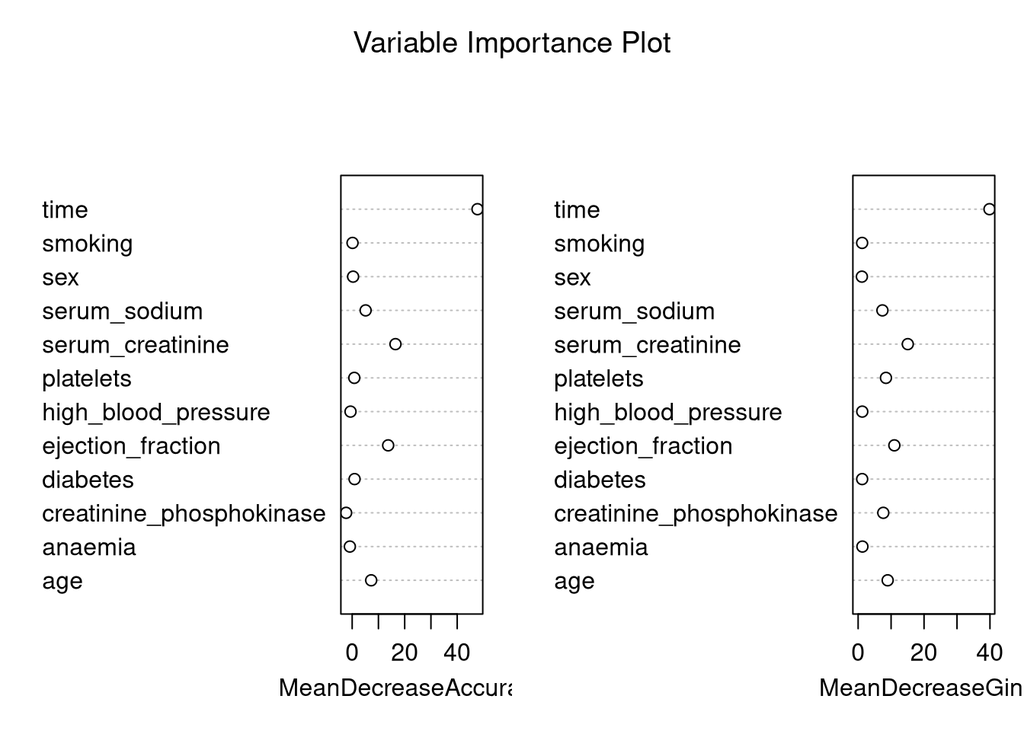

```r
randomForest::varImpPlot(model,
                         sort=FALSE,
                         main="Variable Importance Plot")
```

*Ejection fraction* is the amount of blood a heart pumps each time it beats. It is calculated by dividing the *stroke volume* by the *end-diastolic volume*, all multiplied by 100. An ejection fraction of 50-70% is considered healthy. A low ejection fraction rate is an indicator of heart failure and/or heart disease.

Although the numbers are slightly lower, *time*, *serum_creatinine*, and *ejection_fraction* are also the top three variables for predicting heart failure according to the Mean Decrease Gini Index plot. We note that the information provided by these plots is slightly different than the results provided by the Gini Index table seen previously. The Gini Index table suggests smoking, high blood pressure, and creatine phosphokinase are the top three variables for classification of heart failure. We recognize that all sources of analysis must be double-checked and weighed before achieving a final conclusion.

```r
prediction <- predict(model, newdata = heart_test)


cf <- confusionMatrix(prediction, heart_test$DEATH_EVENT, positive = "1", mode = "everything")
cf
```

```
Confusion Matrix and Statistics

          Reference
Prediction  0  1
         0 37  6
         1  5 12

               Accuracy : 0.8167
                 95% CI : (0.6956, 0.9048)
    No Information Rate : 0.7
    P-Value [Acc > NIR] : 0.02948

                  Kappa : 0.5565

 Mcnemar's Test P-Value : 1.00000

            Sensitivity : 0.6667
            Specificity : 0.8810
         Pos Pred Value : 0.7059
         Neg Pred Value : 0.8605
              Precision : 0.7059
                 Recall : 0.6667
                     F1 : 0.6857
             Prevalence : 0.3000
         Detection Rate : 0.2000
   Detection Prevalence : 0.2833
      Balanced Accuracy : 0.7738

       'Positive' Class : 1
```

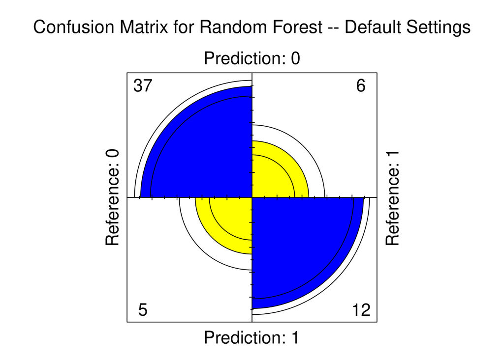

```r
# Produce plot of the confusion matrix

fourfoldplot(as.table(cf),color=c("yellow","blue"),main = "Confusion Matrix for Random Forest -- Default Settings")
```

[figure not shown]

```r
# The code below creates a heatmap from the values provided in the confusion matrix.
# Notice the values are hard-coded and do not come from an existing data structure.
# https://stackoverflow.com/questions/7421503/how-to-plot-a-confusion-matrix-using-heatmaps-in-r

library("dplyr")
library("tidyr")

# Loading the confusion matrix
hm <- readr::read_delim("y FALSE TRUE
FALSE 3 17
TRUE 36 4", delim = " ")

hm <- hm %>% gather(x, value, "FALSE":"TRUE")


library("ggplot2")
ggplot(hm, aes(x=x, y=y, fill=value)) + geom_tile() +
  scale_x_discrete(label = c("TRUE", "FALSE")) +
  labs(title="Confusion Matrix Heatmap", x="Predicted Values", y="Actual Values") +
  geom_text(aes(label=value), color="black") +
  scale_fill_distiller(palette="Blues", direction = 1)
```

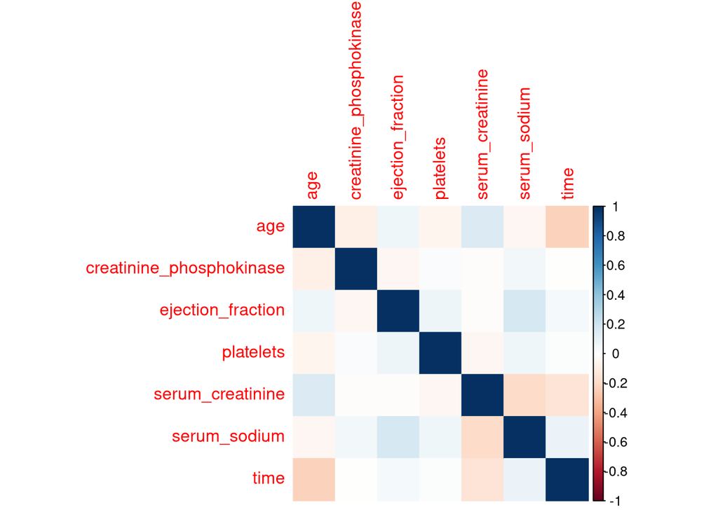

```r
# Draws the corelation heatmap
corrplot(cor_matrix, method = "color")
```

Variable correlation is used to explore the data to understand relationships that might otherwise go unnoticed. In some cases, understanding correlation can lead to the discovery of one variable causing another variable. Furthermore, we also recognize that correlation does not always mean causation, so we are careful to make such a claim. We recognize that further analysis and subject matter expertise is required to arrive at such a conclusion.

```r
# Create prediction matrix and utilize it to generate ROC values that can be graphed
prediction <- predict(model, heart_test, type = "prob")
prediction
```

```
       0     1
1  0.250 0.750
2  0.096 0.904
3  0.260 0.740
4  0.326 0.674
5  0.182 0.818
6  0.158 0.842
7  0.098 0.902
8  0.266 0.734
9  0.058 0.942
10 0.128 0.872
11 0.186 0.814
12 0.390 0.610
13 0.336 0.664
14 0.888 0.112
```

[output cut: 48 more lines]

```r
library(pROC)
ROC_rf <- roc(heart_test$DEATH_EVENT, prediction[,2])

# Generate Area Under Curve (AUC) for ROC curve (higher -> better)
ROC_rf_auc <- auc(ROC_rf)
```

The table above shows the classification prediction probabilities for each observation in the test dataset. Rather than just stating how each observation is classified, it is useful to state the probability of that classification as well. In this case, “0” means a classification of no heart failure and “1” means a classification of heart failure. Understanding classification probabilities provides insight into how statistically strong a prediction is. For example, record 7 above shows a probability of 0.098 for no heart failure and 0.902 for heart failure. This can be interpreted as strong confidence in this particular classification instance. On the other hand, record 58 shows probabilities of 0.540 and 0.460, which means the confidence is almost split evenly between the two possibilities.

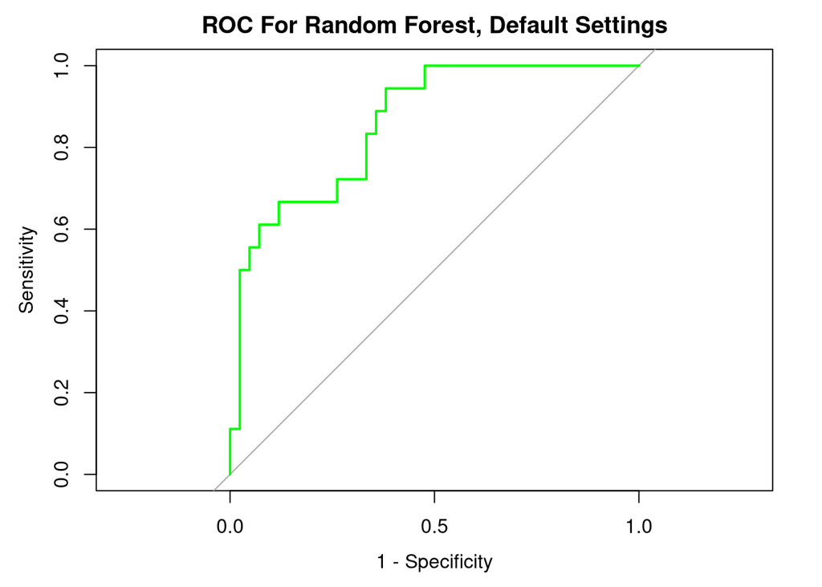

```r
# Plot ROC curves
plot(ROC_rf, col = "green", legacy.axes = TRUE, main = "ROC For Random Forest, Default Settings")
```

```r
# Print the performance of each model
paste("Accuracy % of default random forest: ", mean(heart_test$DEATH_EVENT == round(prediction[,2], digits = 0)))
```

```
[1] "Accuracy % of default random forest:  0.816666666666667"
```

```r
paste("Area under curve of default random forest: ", ROC_rf_auc)
```

```
[1] "Area under curve of default random forest:  0.858465608465608"
```

The ROC (receiver operating characteristic) curve above provides a graphical representation of the true positive rate along the Y-axis vs. the false positive rate along the X-axis. This is slightly different than accuracy (shown above the ROC curve), which is just a percentage of correct predictions. The diagonal line of the ROC curve represents what the accuracy is expected to be if the data points are classified at random. The closer a curve is to the top left corner, the more accurate the model is. Perfect classification is 100%. The output above shows the classification accuracy with the default hyperparameters for the randomForest package comes to 81.67% and the area under the ROC curve is 85.85%. In this case, these are considered indications of strong accuracy.

### Tuning the Random Forest Model

A random search algorithm is used to select an optimum (tuned) mtry value. The mtry value is the number of randomly drawn candidate variables. The variable “mtry” should be read as “m-try” and it means the “number of variables tried to split a node” (Genuer and Poggi 2020).

```r
ncol(heart_train)
```

```
[1] 13
```

The output above confirms we have 13 variables (columns) in our dataset.

```r
# Implement a random search for tuned mtry
control <- trainControl(method="repeatedcv", number=10, repeats=3, search="random")
metric <- "Accuracy"
mtry <- sqrt(ncol(heart_train))
rf_random <- train(DEATH_EVENT~., data=heart_train, method="rf", metric=metric, tuneLength=13, trControl=control)
print(rf_random)
```

```
Random Forest

239 samples
 12 predictor
  2 classes: '0', '1'

No pre-processing
Resampling: Cross-Validated (10 fold, repeated 3 times)
Summary of sample sizes: 215, 215, 216, 214, 215, 215, ...
Resampling results across tuning parameters:

  mtry  Accuracy   Kappa
   2    0.8675942  0.6884010
   3    0.8645797  0.6841239
   4    0.8644034  0.6858183
   5    0.8630145  0.6841326
   7    0.8435000  0.6431955
   9    0.8421667  0.6399868
  10    0.8350459  0.6266929
  11    0.8393382  0.6383974
  12    0.8295507  0.6159840

Accuracy was used to select the optimal model using the largest value.
The final value used for the model was mtry = 2.
```

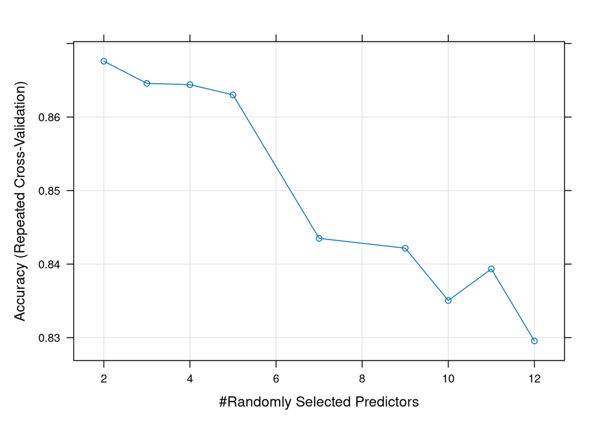

```r
plot(rf_random)
```

The visualization above is the result of running the trainControl() function with *random selection*. This function is used to specify parameters used for training. The visualization above shows the results of running the model with 2, 3, 4, 5, 7, 9, 10, 11, and 12 variables to simulate random selection. The general downward slope of the graph shows performance decreases as the number of parameters increases from 2 to 12. The conclusion is that for a random search the model’s accuracy is the highest when the number of candidate variables (mtry) is 2.

```r
# Use gridsearch to determine best mtry value
control <- trainControl(method="repeatedcv", number=10, repeats=3, search="grid")
tunegrid <- expand.grid(.mtry=c(1:12))
rf_gridsearch <- train(DEATH_EVENT~., data=heart_train, method="rf", metric=metric, tuneGrid=tunegrid, trControl=control)
print(rf_gridsearch)
```

```
Random Forest

239 samples
 12 predictor
  2 classes: '0', '1'

No pre-processing
Resampling: Cross-Validated (10 fold, repeated 3 times)
Summary of sample sizes: 215, 215, 215, 215, 216, 214, ...
Resampling results across tuning parameters:

  mtry  Accuracy   Kappa
   1    0.7759589  0.3881508
   2    0.8638961  0.6790539
   3    0.8596184  0.6759849
   4    0.8597343  0.6754085
   5    0.8554469  0.6695923
   6    0.8568961  0.6719707
   7    0.8457295  0.6483644
   8    0.8414976  0.6368253
   9    0.8401135  0.6331559
  10    0.8386087  0.6300973
  11    0.8345024  0.6212769
  12    0.8274976  0.6082830

Accuracy was used to select the optimal model using the largest value.
The final value used for the model was mtry = 2.
```

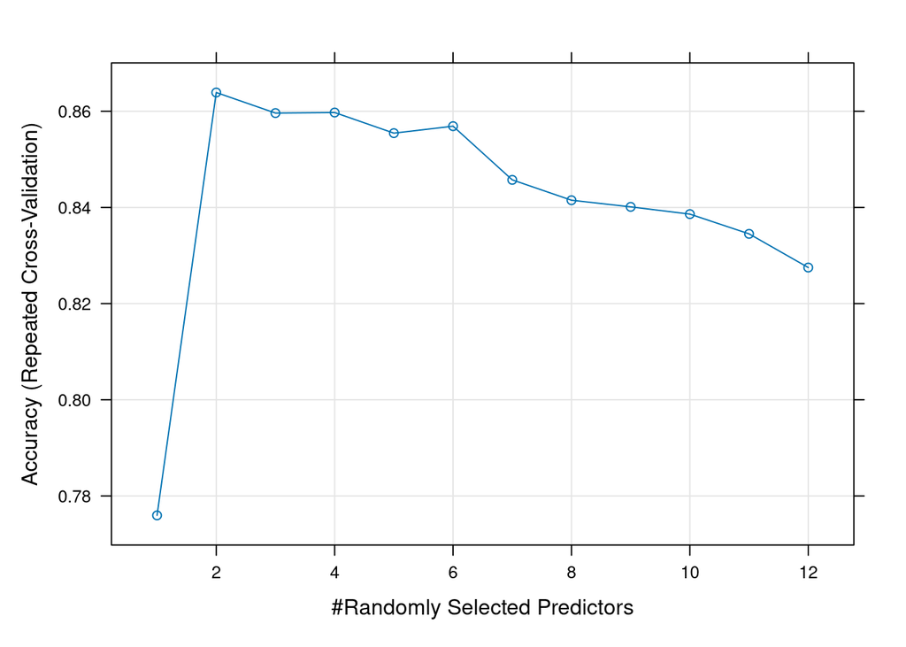

```r
plot(rf_gridsearch)
```

The visualization above is the result of running the trainControl() function and using *grid search* rather than random selection to identify the optimum number of parameters (mtry) to use in the model. The results confirm a peak accuracy when the number of candidtae variables (mtry) is 2. Thus, randomForest model is tested with this optimized mtry value below.

```r
set.seed(123)
model2 <- randomForest(
  formula = DEATH_EVENT~.,
  data = heart_train,
  mtry = 2,
  importance = TRUE
)

model2
```

```
Call:
 randomForest(formula = DEATH_EVENT ~ ., data = heart_train, mtry = 2,      importance = TRUE)
               Type of random forest: classification
                     Number of trees: 500
No. of variables tried at each split: 2

        OOB estimate of  error rate: 12.97%
Confusion matrix:
    0  1 class.error
0 150 11  0.06832298
1  20 58  0.25641026
```

```r
importance(model2)
```

```
                                  0          1 MeanDecreaseAccuracy
age                       3.2540020  7.0557417            7.0824979
anaemia                  -2.9979407 -0.5694724           -2.7130595
creatinine_phosphokinase  1.2985399 -1.6000825            0.1451115
diabetes                 -0.3129181 -1.7068997           -1.4458052
ejection_fraction         9.9638983 10.5525370           13.6350220
high_blood_pressure      -1.4000197  1.3288263           -0.1072657
platelets                 0.7175006  0.6922643            0.9023172
serum_creatinine         13.8178045 11.9915047           17.1191782
serum_sodium              2.7946286  4.5633542            4.7913111
sex                       1.1950761 -1.4033971           -0.2195930
smoking                   1.6537970 -1.2290673            0.5459152
time                     32.8832531 32.3490238           37.2963638
                         MeanDecreaseGini
age                             10.045945
anaemia                          1.543104
creatinine_phosphokinase         8.356436
diabetes                         1.524374
ejection_fraction               11.511277
high_blood_pressure              1.579383
platelets                        8.966627
serum_creatinine                15.153737
serum_sodium                     8.104233
sex                              1.356842
smoking                          1.334717
time                            32.853615
```

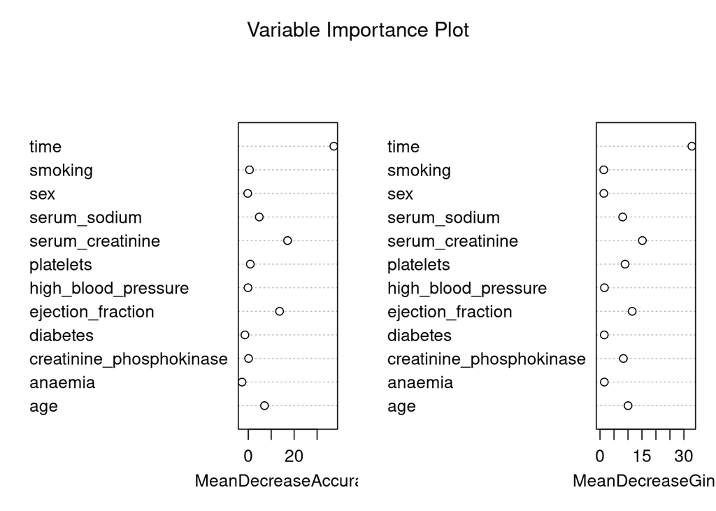

```r
randomForest::varImpPlot(model2,
                         sort=FALSE,
                         main="Variable Importance Plot")
```

The Variable Importance plot above is run with the data from the optimized model. The results appear to be identical to the previous Variable Importance Plot, and there is no noticeable change in the most important variables. The top three most important variables for classification are still *time*, *serum_creatinine*, and *ejection_fraction*.

```r
prediction2 <- predict(model2, newdata = heart_test)


cf2 <- confusionMatrix(prediction2, heart_test$DEATH_EVENT, positive = "1", mode = "everything")
cf2
```

```
Confusion Matrix and Statistics

          Reference
Prediction  0  1
         0 38  6
         1  4 12

               Accuracy : 0.8333
                 95% CI : (0.7148, 0.9171)
    No Information Rate : 0.7
    P-Value [Acc > NIR] : 0.01388

                  Kappa : 0.5902

 Mcnemar's Test P-Value : 0.75183

            Sensitivity : 0.6667
            Specificity : 0.9048
         Pos Pred Value : 0.7500
         Neg Pred Value : 0.8636
              Precision : 0.7500
                 Recall : 0.6667
                     F1 : 0.7059
             Prevalence : 0.3000
         Detection Rate : 0.2000
   Detection Prevalence : 0.2667
      Balanced Accuracy : 0.7857

       'Positive' Class : 1
```

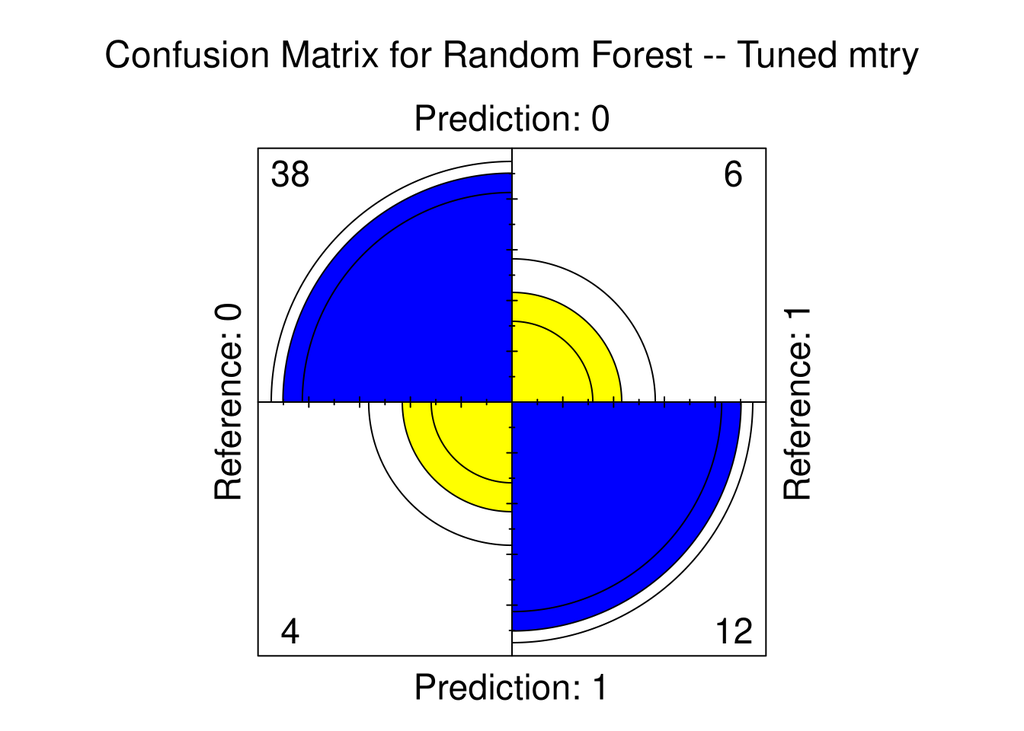

```r
fourfoldplot(as.table(cf2),color=c("yellow","blue"),main = "Confusion Matrix for Random Forest -- Tuned mtry")
```

```r
#set.seed(123)
x <- heart_df[,1:12]
y <- heart_df[,13]

control <- trainControl(method = 'repeatedcv',
                        number = 10,
                        repeats = 3,
                        search = 'grid')
#create tunegrid
tunegrid <- expand.grid(.mtry = c(sqrt(ncol(heart_train))))
modellist <- list()

#train with different ntree parameters
for (ntree in seq(100,1500,100)){
  set.seed(1)
  fit <- train(DEATH_EVENT~.,
               data = heart_train,
               method = 'rf',
               metric = 'Accuracy',
               tuneGrid = tunegrid,
               trControl = control,
               ntree = ntree)
  key <- toString(ntree)
  modellist[[key]] <- fit
}

#Compare results
results <- resamples(modellist)
summary(results)
```

```
Call:
summary.resamples(object = results)

Models: 100, 200, 300, 400, 500, 600, 700, 800, 900, 1000, 1100, 1200, 1300, 1400, 1500
Number of resamples: 30

Accuracy
          Min.   1st Qu.    Median      Mean   3rd Qu.      Max. NA's
100  0.7083333 0.7916667 0.8965217 0.8598357 0.9166667 0.9583333    0
200  0.7083333 0.7916667 0.8750000 0.8584469 0.9166667 0.9583333    0
300  0.7083333 0.7916667 0.8775000 0.8640072 0.9166667 0.9583333    0
400  0.7083333 0.7916667 0.8940217 0.8653406 0.9166667 0.9583333    0
500  0.7083333 0.7916667 0.9130435 0.8681787 0.9191667 0.9583333    0
600  0.7083333 0.7916667 0.8940217 0.8639469 0.9166667 0.9583333    0
700  0.7083333 0.7916667 0.9130435 0.8626184 0.9166667 0.9583333    0
```

[output cut: 26 more lines]

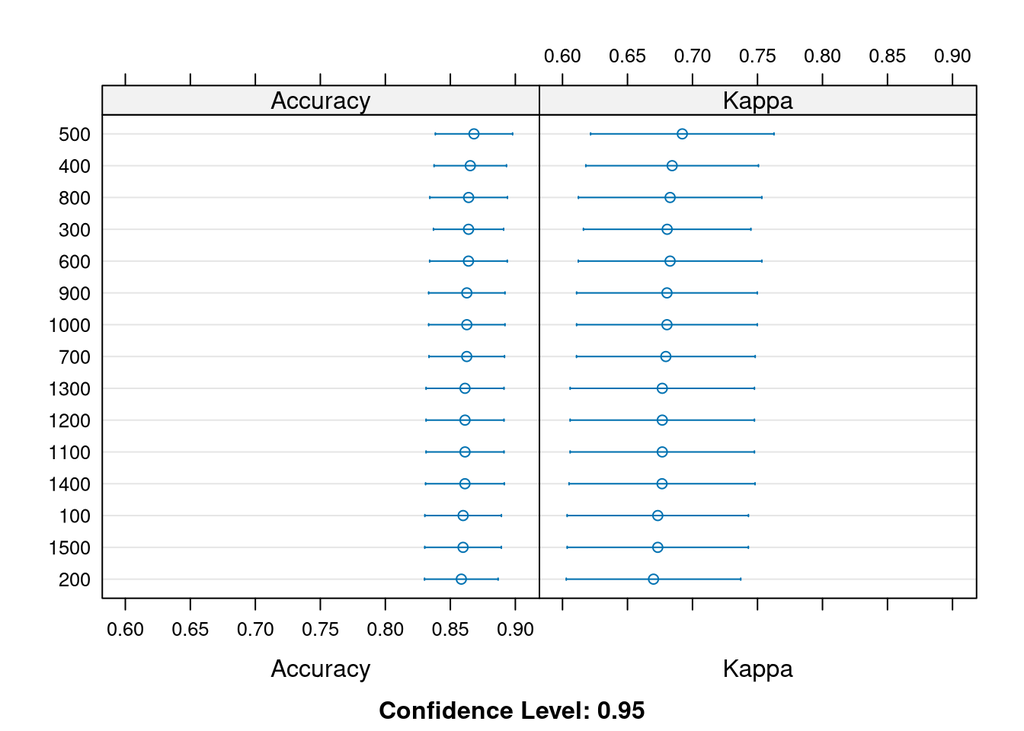

```r
dotplot(results)
```

In the code above the number of trees (ntree) is evaluated over the range 100 to 1500 with increments of 100 trees per set to see if accuracy can be improved by changing this hyperparameter. Note, the default value used previously is ntree = 500.

The results are easiest to understand by reviewing the visualization above. The location of the circle in each row of the accuracy visualization on the left shows the greatest accuracy is achieved when the number of trees is 500. Furthermore, the greatest *kappa* value is also achieved when the number of trees is 500. Cohen’s *kappa* is essentially a measure of “how reliably two raters measure the same thing” (DataTab 2024). Thus, the original model that uses 500 trees as a default value is also the optimum configuration for our model. Therefore, a new model run is not indicated.

```r
prediction2 <- predict(model2, heart_test, type = "prob")
prediction2
```

```
       0     1
1  0.380 0.620
2  0.122 0.878
3  0.326 0.674
4  0.374 0.626
5  0.248 0.752
6  0.268 0.732
7  0.206 0.794
8  0.374 0.626
9  0.086 0.914
10 0.192 0.808
11 0.272 0.728
12 0.488 0.512
13 0.428 0.572
14 0.904 0.096
```

[output cut: 48 more lines]

```r
ROC_rf2 <- roc(heart_test$DEATH_EVENT, prediction2[,2])
# Area Under Curve (AUC) for each ROC curve (higher -> better)
ROC_rf2_auc <- auc(ROC_rf2)
```

The table above shows the classification prediction probabilities for each observation in the modified/tuning dataset. This output is similar to the output for the default dataset. No additional understanding is gained from this. This output is included in the this report for completeness.

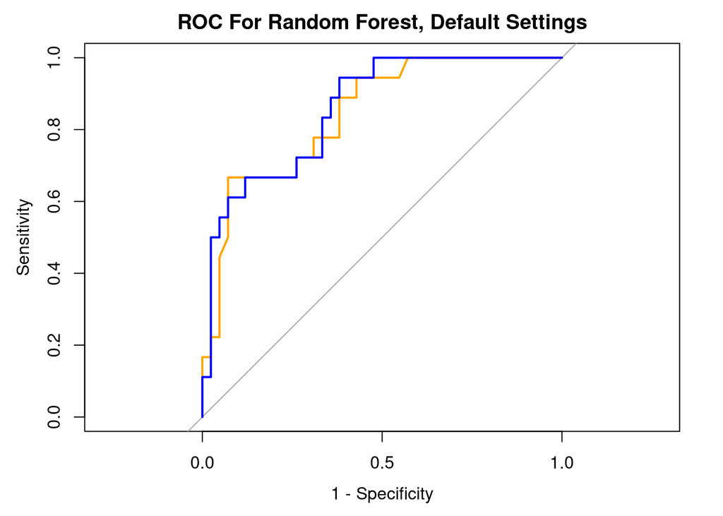

```r
# plot ROC curves
plot(ROC_rf2, col = "orange", legacy.axes = TRUE, main = "ROC For Random Forest, Default Settings")
lines(ROC_rf, col = "blue", legacy.axes = TRUE)
```

```r
# print the performance of each model
paste("Accuracy % of default random forest: ", mean(heart_test$DEATH_EVENT == round(prediction[,2], digits = 0)))
```

```
[1] "Accuracy % of default random forest:  0.816666666666667"
```

```r
paste("Area under curve of default random forest: ", ROC_rf_auc)
```

```
[1] "Area under curve of default random forest:  0.858465608465608"
```

```r
paste("Accuracy % of tuned random forest: ", mean(heart_test$DEATH_EVENT == round(prediction2[,2], digits = 0)))
```

```
[1] "Accuracy % of tuned random forest:  0.833333333333333"
```

```r
paste("Area under curve of tuned random forest: ", ROC_rf2_auc)
```

```
[1] "Area under curve of tuned random forest:  0.843915343915344"
```

Furthermore, the tuned model has a slightly better *accuracy* at 83.33% vs. 81.66% for the default model. The apparent conflict between *performance* and *accuracy* is resolved by understanding the area under the curve is based on actual values and the accuracy is calculated from expected values. Each is measuring something different.

### Model Results

Model Results

Model

Te sting Acc

Prec ision

R ecall

F1 Score

AU C-ROC

Model 1 (def ault)

0 .8167

0 .7059

0 .6667

0 .6857

0 .7738

0 .8585

Model 2 ( Tuned mtry)

**0.8 333**

**0.7 500**

0 .6667

**0.7 059**

**0.7 857**

0 .8439

The testing accuracies of both models are slightly lower than their respective training accuracies which indicates overfitting of the training dataset. We suspect this is caused by the training dataset being too small, or too noisy. This is a small concern and its resolution is out of scope for this report.

The second model (Model 2) the OOB error is 12.97% which translates to a training accuracy of 87.03%. The testing accuracy is 0.8333 (83.33%). The precision value comes to 0.7500 which indicates that the observations predicted as positive are truly positive 75% of the time. The recall is 66.67% which suggests that this model detects positive cases from the samples of true positives in the data about 67% of the time. The F1 score is 70.59% which is the harmonic mean of the model’s precision and recall. Lastly the balanced accuracy is 78.57% which is the average of the models true positive and true negative.

The performance of model 2 is better than model 1. This is based off of the model’s training and testing accuracies; precision; F1; and balanced accuracy as they are all higher than those of the default model. The F1 provides the overall performance of the model since it is a combination of the precision and recall percentages. The balanced accuracy is the average accuracy of classifications for both classes. The recall did not change between models. This metric is of particular importance as it is vital in cases such as heart failure prediction – a higher recall translates to a decrease in false negatives at the expense of a decrease in precision (which equates to an increase in false positives). It is typically more important to not fail to detect positive cases than to have a positive diagnosis for risk of heart failure that is a ‘false alarm.’ The ROC-AUC for the tuned model was found to be slightly lower than the default model’s (0.8439 vs 0.8585). This suggests that although the tuned model is more *accurate*, it did not *perform* as well as the default model.

Although we know which patients Random Forest classifies for heart failure, we do not know how Random Forest comes to these decisions. This is consistent with black-box machine learning. The variable importance plot provides some indication of which variables influence the classification process, but we can never know for certain. The variable importance plots for each model reveal that the top three features with the greatest influence on heart failure prediction are *time* before follow-up visit, *serum creatinine* levels, and *ejection fraction* amount. *Age* of the patient and *serum sodium* amount also have an influence over classification, but to a lesser degree.

## Conclusion

We began by asserting the importance of correctly classifying a person at risk for heart failure. This analysis is made easier with the automated machine learning *decision tree*. This approach, however, is challenged by poor-partitioning, noise, and long compute time. Leo Breiman addresses these issues with his proposal of the Random Forest model which exploits the power of random data subset selection, ensemble learning via multiple decision trees, and an algorithm that supports both hardware and software optimization (Breiman 2001).

The Random Forest model is applied to a heart failure dataset of patients from Faisalabad Pakistan. The Random Forest model provides strong classification results with its default settings. The model is tuned to generate an OOB Error of 12.97%, a training accuracy of 87.03%, a testing accuracy of 83.33%, a precision score of .7500, a recall score of .6667, an F1 score of .7059, a balanced accuracy of .7857, and an AUC-ROC score of .8439. We consider these results to be strong for automated analysis.

Random Forest makes its decisions in a *black box*, which means we do not fully understand how it classifies data or which variables are used. We do know from a review of the variable importance plot that *time before follow-up visit*, *serum creatinine levels*, and *ejection fraction amount* are all likely influential in the classification process. A review of the Gini Index table suggests *smoking*, *high blood pressure*, and *creatine phosphokinase* are also strong contributors.

## References

Boryczka, Urszula, and Jan Kozak. 2011. “New Insights of Cooperation Among Ants in Ant Colony Decisioon Trees.” *Third World Congress on Nature & Biologically Inspired Computing*, 255–60.

Breiman, Leo. 2001. “Random Forests.” *Machine Learning* 45: 5–32.

Brieuc, Marine SO, Charles D Waters, Daniel P Drinan, and Kerry A Naish. 2018. “A Practical Introduction to Random Forest for Genetic Association Studies in Ecology and Evolution.” *Molecular Ecology Resources* 18 (4): 755–66.

Brodersen, Kay Henning, Cheng Soon Ong, Klaas Enno Stephan, and Joachim M Buhmann. 2010. “The Balanced Accuracy and Its Posterior Distribution.” In *2010 20th International Conference on Pattern Recognition*, 3121–24. IEEE.

Casanova, Ramon, Santiago Saldana, Emily Y Chew, Ronald P Danis, Craig M Greven, and Walter T Ambrosius. 2014. “Application of Random Forests Methods to Diabetic Retinopathy Classification Analyses.” *PLOS One* 9 (6): e98587.

Chicco, Davide, and Giuseppe Jurman. 2020. “Machine Learning Can Predict Survival of Patients with Heart Failure from Serum Creatinine and Ejection Fraction Alone.” *BMC Medical Informatics and Decision Making* 20: 1–16.

DataTab. 2024. “Cohen’s Kappa.” https://datatab.net/tutorial/cohens-kappa.

Esmaily, Habibollah, Maryam Tayefi, Hassan Doosti, Majid Ghayour-Mobarhan, Hossein Nezami, and Alireza Amirabadizadeh. 2018. “A Comparison Between Decision Tree and Random Forest in Determining the Risk Factors Associated with Type 2 Diabetes.” *Journal of Research in Health Sciences* 18 (2): 412.

Genuer, Robin, and Jean-Michael Poggi. 2020. *Random Forest with r*. Springer.

Hastie, Trevor, Robert Tibshirani, and Jerome Friednman. 2001. *Elements of Statistical Learning*. Springer of New York.

“Heart Failure Clinical Records.” 2020. UCI Machine Learning Repository.

Huang, Jin, and C. X. Ling. 2005. “Using AUC and Accuracy in Evaluating Learning Algorithms.” *IEEE Transactions on Knowledge and Data Engineering* 17 (3): 299–310. https://doi.org/10.1109/TKDE.2005.50.

James, Gareth, Daniela Witten, Hastie Trevor, and Robert Tibshirani. 2021. *An Introduction to Statistical Learning, 2nd Edition*. Springer of New York.

Lin, Ke, Yonghua Hu, and Guilan Kong. 2019. “Predicting in-Hospital Mortality of Patients with Acute Kidney Injury in the ICU Using Random Forest Model.” *International Journal of Medical Informatics* 125: 55–61.

Luo, Guoliang, Yean Zhu, Rui Wang, Yang Tong, Wei Lu, and Haolun Wang. 2020. “Random Forest–Based Classsification and Analysis of Hemiplegia Gait Using Low-Cost Depth Cameras.” *Medical & Biological Engineering & Computing* 58: 373–82.

Maechler, Martin. 2024. “R-Manual.” https://stat.ethz.ch/R-manual/R-devel/library/graphics/html/fourfoldplot.html.

Mascaro, Joseph, Gregory P Asner, David E Knapp, Ty Kennedy-Bowdoin, Roberta E Martin, Christopher Anderson, Mark Higgins, and K Dana Chadwick. 2014. “A Tale of Two ‘Forests’: Random Forest Machine Learning Aids Tropical Forest Carbon Mapping.” *PloS One* 9 (1): e85993.

Moradi, Mohammadamin, Zheng-Meng Zhai, Aaron Nielsen, and Ying-Cheng Lai. 2024. “Random Forests for Detecting Weak Signals and Extracting Physical Information: A Case Study of Magnetic Navigation.” *APL Machine Learning* 2 (1).

Quinlan, J. R. 1986. “Induction of Decision Trees.” *Machine Learning* 1: 81–106.

Rachmawanto, Eko Hari, De Rosal Ignatious Moses Setiadi, Nova Rijati, Ajib Susanto, Ibnu Utomo Wahyu Mulyono, and Hidayah Rahmalan. 2021. “Attribute Selection Analysis for the Random Forest Classification in Unbalanced Diabetes Dataset.” *2021 International Seminar on Application for Technology of Informatoon and Communication (iSemantic)*, 82–86.

Raschka, Sebastian, Yuxi Hayden Liu, and Vahid Mirjalili. 2022. *Machine Learning with PyTorch and Scikit-Learn: Develop Machine Learning and Deep Learning Models with Python*. Packt Publishing Ltd.

Sheppard, Clinton. 2017. *Tree-Based Machine Learning Algorithms; Decision Trees, Random Forests, and Boosting*. CreateSpace Independent Publishing Platform.

Wang, Huaizhi, Yangyang Liu, Bin Zhou, Canbing Li, Guangzhong Cao, Nikolai Voropai, and Evgeny Barakhtenko. 2020. “Taxonomy Research of Artificial Intelligence for Deterministic Solar Power Forecasting.” *Energy Conversion and Management* 214: 112909.

Yuan, Fangfang, Fusheng Lian, Xingjian Xu, and Zhaohua Ji. 2015. “Decision Tree Algorithm OPtimization Research Based on MapReduce.” *2015 6th IEEE International Conference on Software Engineering and Service Science (ICSESS)*, 1010–13.

Zhao, Jing, Shaopeng Gu, and Adam McDermaid. 2019. “Predicting Outcomes of Chronic Kidney Disease from EMR Data Based on Random Forest Regression.” *Mathematical Biosciences* 310: 24–30.